# midterm

2024-10-07

```r
data <- data.frame(read.csv("googleplaystore.csv"))
```

# Apps

```r
library(ggplot2)

#Display all the duplicated Apps
duplicate_apps <- aggregate(App ~ ., data = data, FUN = length)
duplicate_apps <- duplicate_apps[duplicate_apps$App > 1, ]
duplicate_apps <- duplicate_apps[order(-duplicate_apps$App), ]
#View(duplicate_apps)
#print(duplicate_apps)
print(paste("Number of duplicated Apps:",nrow(duplicate_apps)))
```

```
## [1] "Number of duplicated Apps: 404"
```

```r
#Removing Na values and duplicates
data_clean <- data[!is.na(data$App), ]
data_clean <- data_clean[!duplicated(data_clean$App), ]

#(After removing the duplicates)Unique values
unique_apps <- length(unique(data_clean$App))
print(paste("Number of unique apps after removing the duplicates:", unique_apps))
```

```
## [1] "Number of unique apps after removing the duplicates: 9660"
```

Nearly 404 apps have been repeated twice and thrice. After removing all the duplicated app names, there are 9660 unique apps in the data frame. (1181 values removed)

Below is the dataframe with number of unique values and NA value for each variables in the dataset after removing the duplicates.

```r
#DataFrame includes unique values and Na for all variables in data after removing duplicates
unique_values_list <- lapply(data_clean, unique)
unique_counts_list <- lapply(data_clean, function(col) length(unique(col)))
null_counts_list <- lapply(data_clean, function(col) sum(is.na(col)))

unique_df <- data.frame(
  Unique_Values = sapply(unique_values_list, function(x) paste(x, collapse = ", ")),
  Unique_Counts = unlist(unique_counts_list),
  Null_Counts = unlist(null_counts_list)
)
```

# Price

```r
typeof(data_clean$Price)
```

```
## [1] "character"
```

Convert Price to numerical is required

```r
#To check if there is dollar symbol present
#data_clean$Price[]
```

```r
# Remove dollar symbols and convert to numeric
data_clean$Price <- as.numeric(gsub("\\$", "", data_clean$Price))
```

```r
#Recheck for dollar symbol
#data_clean$Price[]
```

```r
# Summary statistics for price
summary(data_clean$Price)
```

```
##    Min. 1st Qu.  Median    Mean 3rd Qu.    Max.    NA's
##   0.000   0.000   0.000   1.099   0.000 400.000       1
```

From the unique_df, there is a missing value present in the Price column.

```r
#Checking for missing values in Price
missing_na <- is.na(data_clean$Price)
missing_blank <- data_clean$Price == ""

sum(missing_na)
```

```
## [1] 1
```

```r
sum(missing_blank, na.rm = TRUE)
```

```
## [1] 0
```

```r
# Remove row where Price is NA or blank
data_clean <- data_clean[!is.na(data_clean$Price) & data_clean$Price != "", ]
```

Have removed one row #10473 which app does not have a category name.(not required)

```r
#Recheck for missing values
summary(data_clean$Price)
```

```
##    Min. 1st Qu.  Median    Mean 3rd Qu.    Max.
##   0.000   0.000   0.000   1.099   0.000 400.000
```

Missing values removed succesfully.(Price)

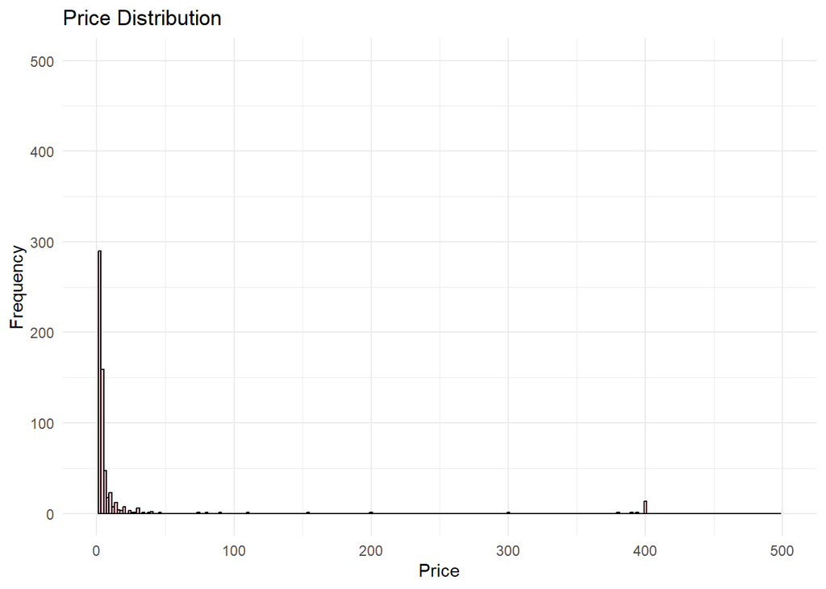

```r
#Checking the distribution of prices using histogram
library(ggplot2)

ggplot(data_clean, aes(x=Price)) +
  geom_histogram(binwidth=2, fill="pink", color="black") +
   xlim(0, 500) + ylim(0, 500) +
  labs(title="Price Distribution", x="Price", y="Frequency") +
  theme_minimal()
```

The data is highly skewed as there are many zero price entries.

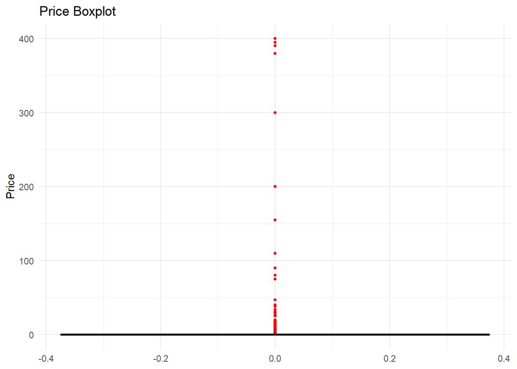

```r
# Boxplot for the same
ggplot(data_clean, aes(y=Price)) +
  geom_boxplot(outlier.colour = "red", outlier.shape = 16, outlier.size = 1, fill="pink", color="black") +
  labs(title="Price Boxplot", y="Price") +
  theme_minimal()
```

```r
outlierKD2 <- function(df, var, rm = FALSE, boxplt = FALSE, histogram = TRUE, qqplt = FALSE) {
  dt <- df  # Duplicate the dataframe for potential alteration
  var_name <- eval(substitute(var), eval(dt))
  na1 <- sum(is.na(var_name))
  m1 <- mean(var_name, na.rm = TRUE)
  colTotal <- boxplt + histogram + qqplt  # Calculate the total number of charts to be displayed
  par(mfrow = c(2, max(2, colTotal)), oma = c(0, 0, 3, 0))  # Adjust layout for plots

  # Q-Q plot with custom title
  if (qqplt) {
    qqnorm(var_name, main="Q-Q plot without Outliers")
    qqline(var_name)
  }

  # Histogram with custom title
  if (histogram) {
    hist(var_name,main = "Histogram without Outliers", xlab = NA, ylab = NA)
  }

  # Box plot with custom title
  if (boxplt) {
    boxplot(var_name, main= "Box Plot without Outliers")
  }

  # Identify outliers
  outlier <- boxplot.stats(var_name)$out
  mo <- mean(outlier)
  var_name <- ifelse(var_name %in% outlier, NA, var_name)

  # Q-Q plot without outliers
  if (qqplt) {
    qqnorm(var_name, main="Q-Q plot with Outliers")
    qqline(var_name)
  }

  # Histogram without outliers
  if (histogram) {
    hist(var_name, main = "Histogram with Outliers", xlab = NA, ylab = NA)
  }

  # Box plot without outliers
  if (boxplt) {
    boxplot(var_name, main = "Boxplot with Outliers")
  }

  # Add the title for the overall plot section if any plots are displayed
  if (colTotal > 0) {
    title("Outlier Check", outer = TRUE)
    na2 <- sum(is.na(var_name))
    cat("Outliers identified:", na2 - na1, "\n")
    cat("Proportion (%) of outliers:", round((na2 - na1) / sum(!is.na(var_name)) * 100, 1), "\n")
    cat("Mean of the outliers:", round(mo, 2), "\n")
    cat("Mean without removing outliers:", round(m1, 2), "\n")
    cat("Mean if we remove outliers:", round(mean(var_name, na.rm = TRUE), 2), "\n")
  }

  # Remove outliers if `rm = TRUE`
  if (rm) {
    dt[as.character(substitute(var))] <- invisible(var_name)
    cat("Outliers successfully removed", "\n")
    return(invisible(dt))
  } else {
    cat("Nothing changed", "\n")
    return(invisible(df))
  }
}
```

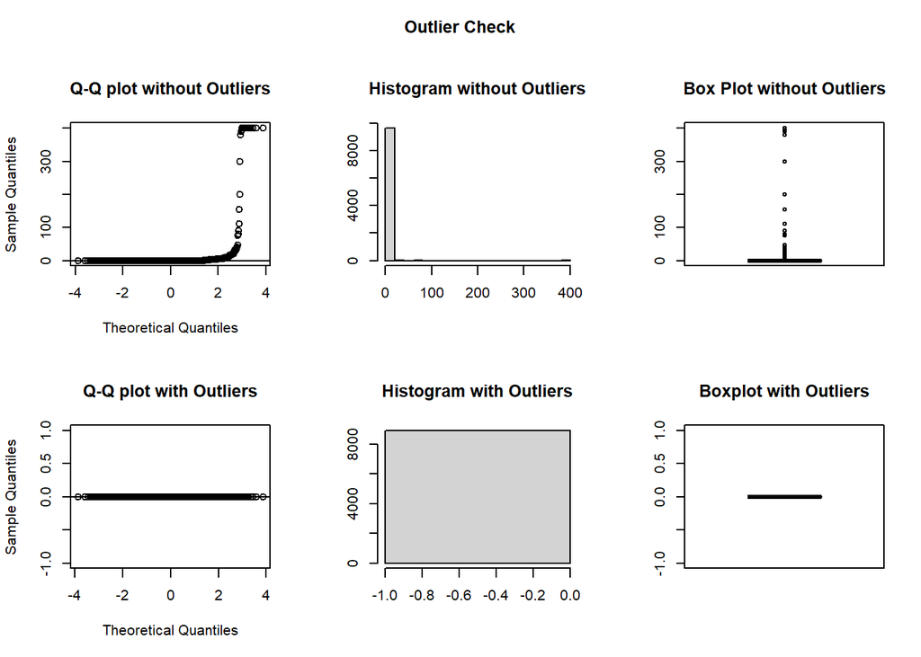

```
## Outliers identified: 756
## Proportion (%) of outliers: 8.5
## Mean of the outliers: 14.05
## Mean without removing outliers: 1.1
## Mean if we remove outliers: 0
## Nothing changed
```

```r
outlier_check_price = outlierKD2(data_clean, Price, rm = FALSE, boxplt = TRUE, qqplt = TRUE)
```

The price values here are valid observations for our analysis(both typical and extreme values), so removing these outliers might not be useful.

```r
#To check the value ranges
table(data_clean$Price)
```

```
##
##      0   0.99      1   1.04    1.2   1.26   1.29   1.49    1.5   1.59   1.61
##   8903    145      3      1      1      1      1     46      1      1      1
##    1.7   1.75   1.76   1.96   1.97   1.99      2   2.49    2.5   2.56   2.59
##      2      1      1      1      1     73      3     25      1      1      1
##    2.6    2.9   2.95   2.99   3.02   3.04   3.08   3.28   3.49   3.61   3.88
##      1      1      1    124      1      1      1      1      7      1      1
##    3.9   3.95   3.99   4.29   4.49   4.59    4.6   4.77    4.8   4.84   4.85
##      1      1     57      1      9      1      1      1      1      1      1
##   4.99      5   5.49   5.99   6.49   6.99   7.49   7.99   8.49   8.99      9
##     70      1      5     26      5     11      2      7      2      5      1
##   9.99     10  10.99  11.99  12.99  13.99     14  14.99  15.46  15.99  16.99
##     19      2      2      3      4      2      1      9      1      1      2
##  17.99  18.99   19.4   19.9  19.99  24.99  25.99  28.99  29.99  30.99  33.99
##      2      1      1      1      5      3      1      1      5      1      1
##  37.99  39.99  46.99  74.99  79.99  89.99 109.99 154.99    200 299.99 379.99
##      1      2      1      1      1      1      1      1      1      1      1
## 389.99 394.99 399.99    400
##      1      1     12      1
```

# Type

```r
table(data_clean$Type)
```

[output not shown]

```r
#Missing values
print(paste("Missing values:",sum(is.na(data_clean$Type))))
```

```
## [1] "Missing values: 0"
```

```r
data_clean[is.na(data_clean$Type), ]
```

```
##  [1] App            Category       Rating         Reviews        Size
##  [6] Installs       Type           Price          Content.Rating Genres
## [11] Last.Updated   Current.Ver    Android.Ver
## <0 rows> (or 0-length row.names)
```

```r
# Replace NaN or missing values in the Type column with "Free"
data_clean$Type[is.na(data_clean$Type)] <- "Free"
```

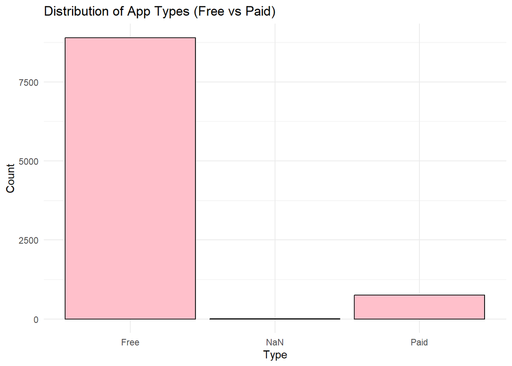

```r
ggplot(data_clean, aes(x = Type)) +
  geom_bar(fill = "pink", color = "black") +
  labs(title = "Distribution of App Types (Free vs Paid)", x = "Type", y = "Count") +
  theme_minimal()
```

```r
data_clean$Type <- as.factor(data_clean$Type)


summary_by_type <- data.frame(
  Type = levels(data_clean$Type),
  Min_Price = tapply(data_clean$Price, data_clean$Type, min, na.rm = TRUE),
  Max_Price = tapply(data_clean$Price, data_clean$Type, max, na.rm = TRUE),
  Mean_Price = tapply(data_clean$Price, data_clean$Type, mean, na.rm = TRUE),
  Median_Price = tapply(data_clean$Price, data_clean$Type, median, na.rm = TRUE)
)


print(summary_by_type)
```

```
##      Type Min_Price Max_Price Mean_Price Median_Price
## Free Free      0.00         0    0.00000         0.00
## NaN   NaN      0.00         0    0.00000         0.00
## Paid Paid      0.99       400   14.04515         2.99
```

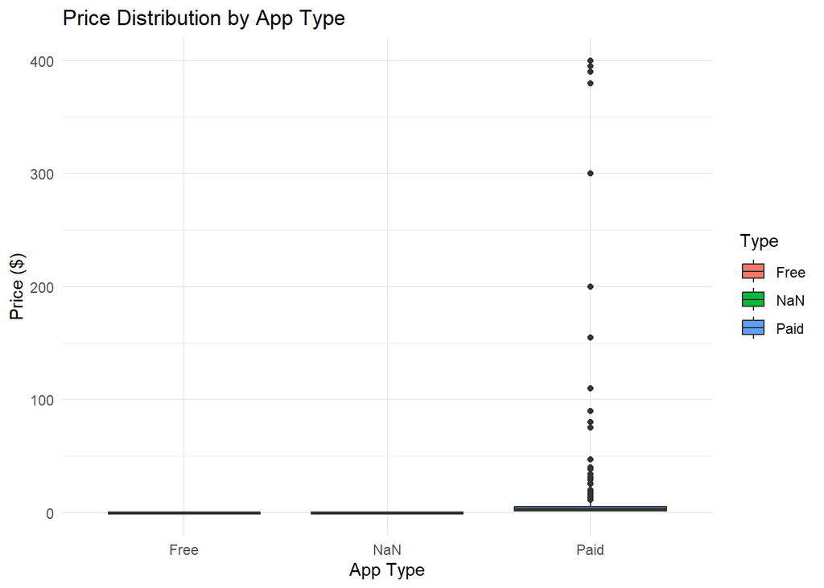

```r
ggplot(data_clean, aes(x = Type, y = Price, fill = Type)) +
  geom_boxplot() +
  labs(title = "Price Distribution by App Type",
       x = "App Type",
       y = "Price ($)") +
  theme_minimal()
```

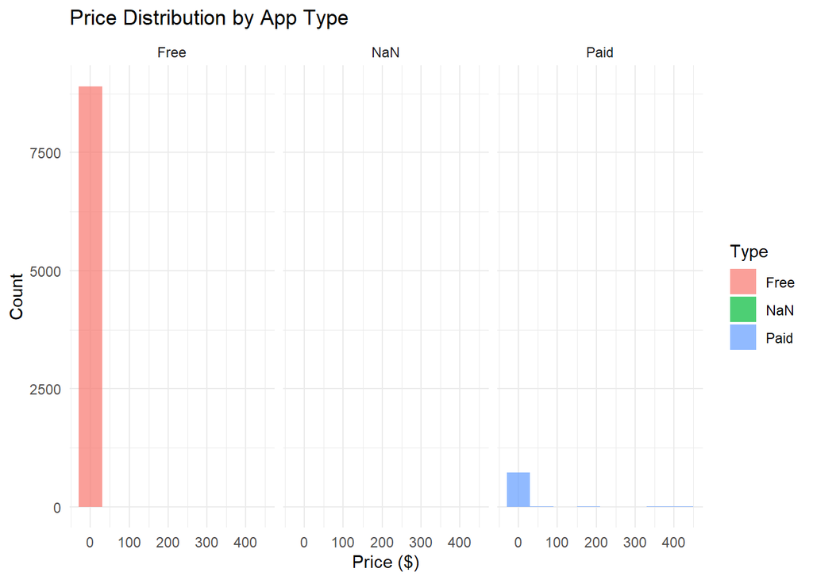

```r
ggplot(data_clean, aes(x = Price, fill = Type)) +
  geom_histogram(binwidth = 60, alpha = 0.7, position = "identity") +
  facet_wrap(~ Type) +
  labs(title = "Price Distribution by App Type",
       x = "Price ($)",
       y = "Count") +
  theme_minimal()
```

Here, by analysing the price distribution by app types, there are some incorrect values in the Type column that are not correctly representing the price of the apps. Hence, as we can completely relu on the prices, the type column is not required for our analysis.

Removing Type column…

```r
#Using subset function
data_clean <- subset(data_clean, select = -Type)
```

```r
str(data_clean)
```

```
## 'data.frame':    9659 obs. of  12 variables:
##  $ App           : chr  "Photo Editor & Candy Camera & Grid & ScrapBook" "Coloring book moana" "U Launcher Lite – FREE Live Cool Themes, Hide Apps" "Sketch - Draw & Paint" ...
##  $ Category      : chr  "ART_AND_DESIGN" "ART_AND_DESIGN" "ART_AND_DESIGN" "ART_AND_DESIGN" ...
##  $ Rating        : num  4.1 3.9 4.7 4.5 4.3 4.4 3.8 4.1 4.4 4.7 ...
##  $ Reviews       : chr  "159" "967" "87510" "215644" ...
##  $ Size          : chr  "19M" "14M" "8.7M" "25M" ...
##  $ Installs      : chr  "10,000+" "500,000+" "5,000,000+" "50,000,000+" ...
##  $ Price         : num  0 0 0 0 0 0 0 0 0 0 ...
##  $ Content.Rating: chr  "Everyone" "Everyone" "Everyone" "Teen" ...
##  $ Genres        : chr  "Art & Design" "Art & Design;Pretend Play" "Art & Design" "Art & Design" ...
##  $ Last.Updated  : chr  "January 7, 2018" "January 15, 2018" "August 1, 2018" "June 8, 2018" ...
##  $ Current.Ver   : chr  "1.0.0" "2.0.0" "1.2.4" "Varies with device" ...
##  $ Android.Ver   : chr  "4.0.3 and up" "4.0.3 and up" "4.0.3 and up" "4.2 and up" ...
```

```r
head(data_clean)
```

```
##                                                  App       Category Rating
## 1     Photo Editor & Candy Camera & Grid & ScrapBook ART_AND_DESIGN    4.1
## 2                                Coloring book moana ART_AND_DESIGN    3.9
## 3 U Launcher Lite – FREE Live Cool Themes, Hide Apps ART_AND_DESIGN    4.7
## 4                              Sketch - Draw & Paint ART_AND_DESIGN    4.5
## 5              Pixel Draw - Number Art Coloring Book ART_AND_DESIGN    4.3
## 6                         Paper flowers instructions ART_AND_DESIGN    4.4
##   Reviews Size    Installs Price Content.Rating                    Genres
## 1     159  19M     10,000+     0       Everyone              Art & Design
## 2     967  14M    500,000+     0       Everyone Art & Design;Pretend Play
## 3   87510 8.7M  5,000,000+     0       Everyone              Art & Design
## 4  215644  25M 50,000,000+     0           Teen              Art & Design
## 5     967 2.8M    100,000+     0       Everyone   Art & Design;Creativity
## 6     167 5.6M     50,000+     0       Everyone              Art & Design
##       Last.Updated        Current.Ver  Android.Ver
## 1  January 7, 2018              1.0.0 4.0.3 and up
## 2 January 15, 2018              2.0.0 4.0.3 and up
## 3   August 1, 2018              1.2.4 4.0.3 and up
## 4     June 8, 2018 Varies with device   4.2 and up
## 5    June 20, 2018                1.1   4.4 and up
## 6   March 26, 2017                1.0   2.3 and up
```

The Type column is successfully removed.

```r
head(data_clean)
```

```
##                                                  App       Category Rating
## 1     Photo Editor & Candy Camera & Grid & ScrapBook ART_AND_DESIGN    4.1
## 2                                Coloring book moana ART_AND_DESIGN    3.9
## 3 U Launcher Lite – FREE Live Cool Themes, Hide Apps ART_AND_DESIGN    4.7
## 4                              Sketch - Draw & Paint ART_AND_DESIGN    4.5
## 5              Pixel Draw - Number Art Coloring Book ART_AND_DESIGN    4.3
## 6                         Paper flowers instructions ART_AND_DESIGN    4.4
##   Reviews Size    Installs Price Content.Rating                    Genres
## 1     159  19M     10,000+     0       Everyone              Art & Design
## 2     967  14M    500,000+     0       Everyone Art & Design;Pretend Play
## 3   87510 8.7M  5,000,000+     0       Everyone              Art & Design
## 4  215644  25M 50,000,000+     0           Teen              Art & Design
## 5     967 2.8M    100,000+     0       Everyone   Art & Design;Creativity
## 6     167 5.6M     50,000+     0       Everyone              Art & Design
##       Last.Updated        Current.Ver  Android.Ver
## 1  January 7, 2018              1.0.0 4.0.3 and up
## 2 January 15, 2018              2.0.0 4.0.3 and up
## 3   August 1, 2018              1.2.4 4.0.3 and up
## 4     June 8, 2018 Varies with device   4.2 and up
## 5    June 20, 2018                1.1   4.4 and up
## 6   March 26, 2017                1.0   2.3 and up
```

```r
tail(data_clean)
```

```
##                                                 App            Category Rating
## 10836                                      FR Forms            BUSINESS    NaN
## 10837                              Sya9a Maroc - FR              FAMILY    4.5
## 10838              Fr. Mike Schmitz Audio Teachings              FAMILY    5.0
## 10839                        Parkinson Exercices FR             MEDICAL    NaN
## 10840                 The SCP Foundation DB fr nn5n BOOKS_AND_REFERENCE    4.5
## 10841 iHoroscope - 2018 Daily Horoscope & Astrology           LIFESTYLE    4.5
##       Reviews               Size    Installs Price Content.Rating
## 10836       0               9.6M         10+     0       Everyone
## 10837      38                53M      5,000+     0       Everyone
## 10838       4               3.6M        100+     0       Everyone
## 10839       3               9.5M      1,000+     0       Everyone
## 10840     114 Varies with device      1,000+     0     Mature 17+
## 10841  398307                19M 10,000,000+     0       Everyone
##                  Genres       Last.Updated        Current.Ver
## 10836          Business September 29, 2016              1.1.5
## 10837         Education      July 25, 2017               1.48
## 10838         Education       July 6, 2018                1.0
## 10839           Medical   January 20, 2017                1.0
## 10840 Books & Reference   January 19, 2015 Varies with device
## 10841         Lifestyle      July 25, 2018 Varies with device
##              Android.Ver
## 10836         4.0 and up
## 10837         4.1 and up
## 10838         4.1 and up
## 10839         2.2 and up
## 10840 Varies with device
## 10841 Varies with device
```

```r
str(data_clean)
```

```
## 'data.frame':    9659 obs. of  12 variables:
##  $ App           : chr  "Photo Editor & Candy Camera & Grid & ScrapBook" "Coloring book moana" "U Launcher Lite – FREE Live Cool Themes, Hide Apps" "Sketch - Draw & Paint" ...
##  $ Category      : chr  "ART_AND_DESIGN" "ART_AND_DESIGN" "ART_AND_DESIGN" "ART_AND_DESIGN" ...
##  $ Rating        : num  4.1 3.9 4.7 4.5 4.3 4.4 3.8 4.1 4.4 4.7 ...
##  $ Reviews       : chr  "159" "967" "87510" "215644" ...
##  $ Size          : chr  "19M" "14M" "8.7M" "25M" ...
##  $ Installs      : chr  "10,000+" "500,000+" "5,000,000+" "50,000,000+" ...
##  $ Price         : num  0 0 0 0 0 0 0 0 0 0 ...
##  $ Content.Rating: chr  "Everyone" "Everyone" "Everyone" "Teen" ...
##  $ Genres        : chr  "Art & Design" "Art & Design;Pretend Play" "Art & Design" "Art & Design" ...
##  $ Last.Updated  : chr  "January 7, 2018" "January 15, 2018" "August 1, 2018" "June 8, 2018" ...
##  $ Current.Ver   : chr  "1.0.0" "2.0.0" "1.2.4" "Varies with device" ...
##  $ Android.Ver   : chr  "4.0.3 and up" "4.0.3 and up" "4.0.3 and up" "4.2 and up" ...
```

## Summary statistics

Table: Statistics summary.

|  | App | Category | Rating | Reviews | Size | Installs | Price | Content.Rating | Genres | Last.Updated | Current.Ver | Android.Ver |
| --- | --- | --- | --- | --- | --- | --- | --- | --- | --- | --- | --- | --- |
| Min | Length:9659 | Length:9659 | Min. :1.000 | Length:9659 | Length:9659 | Length:9659 | Min. : 0.000 | Length:9659 | Length:9659 | Length:9659 | Length:9659 | Length:9659 |
| Q1 | Class :character | Class :character | 1st Qu.:4.000 | Class :character | Class :character | Class :character | 1st Qu.: 0.000 | Class :character | Class :character | Class :character | Class :character | Class :character |
| Median | Mode :character | Mode :character | Median :4.300 | Mode :character | Mode :character | Mode :character | Median : 0.000 | Mode :character | Mode :character | Mode :character | Mode :character | Mode :character |
| Mean | NA | NA | Mean :4.173 | NA | NA | NA | Mean : 1.099 | NA | NA | NA | NA | NA |
| Q3 | NA | NA | 3rd Qu.:4.500 | NA | NA | NA | 3rd Qu.: 0.000 | NA | NA | NA | NA | NA |
| Max | NA | NA | Max. :5.000 | NA | NA | NA | Max. :400.000 | NA | NA | NA | NA | NA |
| NA | NA | NA | NA’s :1463 | NA | NA | NA | NA | NA | NA | NA | NA | NA |

##Change the columns of reviews from Str to int for more knowledge on number of reviews

```
## 'data.frame':    9659 obs. of  12 variables:
##  $ App           : chr  "Photo Editor & Candy Camera & Grid & ScrapBook" "Coloring book moana" "U Launcher Lite – FREE Live Cool Themes, Hide Apps" "Sketch - Draw & Paint" ...
##  $ Category      : chr  "ART_AND_DESIGN" "ART_AND_DESIGN" "ART_AND_DESIGN" "ART_AND_DESIGN" ...
##  $ Rating        : num  4.1 3.9 4.7 4.5 4.3 4.4 3.8 4.1 4.4 4.7 ...
##  $ Reviews       : num  159 967 87510 215644 967 ...
##  $ Size          : chr  "19M" "14M" "8.7M" "25M" ...
##  $ Installs      : chr  "10,000+" "500,000+" "5,000,000+" "50,000,000+" ...
##  $ Price         : num  0 0 0 0 0 0 0 0 0 0 ...
##  $ Content.Rating: chr  "Everyone" "Everyone" "Everyone" "Teen" ...
##  $ Genres        : chr  "Art & Design" "Art & Design;Pretend Play" "Art & Design" "Art & Design" ...
##  $ Last.Updated  : chr  "January 7, 2018" "January 15, 2018" "August 1, 2018" "June 8, 2018" ...
##  $ Current.Ver   : chr  "1.0.0" "2.0.0" "1.2.4" "Varies with device" ...
##  $ Android.Ver   : chr  "4.0.3 and up" "4.0.3 and up" "4.0.3 and up" "4.2 and up" ...
```

Table: Statistics summary.

|  | App | Category | Rating | Reviews | Size | Installs | Price | Content.Rating | Genres | Last.Updated | Current.Ver | Android.Ver |
| --- | --- | --- | --- | --- | --- | --- | --- | --- | --- | --- | --- | --- |
| Min | Length:9659 | Length:9659 | Min. :1.000 | Min. : 0 | Length:9659 | Length:9659 | Min. : 0.000 | Length:9659 | Length:9659 | Length:9659 | Length:9659 | Length:9659 |
| Q1 | Class :character | Class :character | 1st Qu.:4.000 | 1st Qu.: 25 | Class :character | Class :character | 1st Qu.: 0.000 | Class :character | Class :character | Class :character | Class :character | Class :character |
| Median | Mode :character | Mode :character | Median :4.300 | Median : 967 | Mode :character | Mode :character | Median : 0.000 | Mode :character | Mode :character | Mode :character | Mode :character | Mode :character |
| Mean | NA | NA | Mean :4.173 | Mean : 216593 | NA | NA | Mean : 1.099 | NA | NA | NA | NA | NA |
| Q3 | NA | NA | 3rd Qu.:4.500 | 3rd Qu.: 29401 | NA | NA | 3rd Qu.: 0.000 | NA | NA | NA | NA | NA |
| Max | NA | NA | Max. :5.000 | Max. :78158306 | NA | NA | Max. :400.000 | NA | NA | NA | NA | NA |
| NA | NA | NA | NA’s :1463 | NA | NA | NA | NA | NA | NA | NA | NA | NA |

##Checking for Outliers For rating

```r
 breaks = seq(15,20,by = 1)
frequency_table = table(data_clean$Rating)
frequency_table
```

```
##
##   1 1.2 1.4 1.5 1.6 1.7 1.8 1.9   2 2.1 2.2 2.3 2.4 2.5 2.6 2.7 2.8 2.9   3 3.1
##  16   1   3   3   4   8   8  11  12   8  14  20  19  20  24  23  40  45  81  69
## 3.2 3.3 3.4 3.5 3.6 3.7 3.8 3.9   4 4.1 4.2 4.3 4.4 4.5 4.6 4.7 4.8 4.9   5
##  63 100 126 156 167 224 286 359 513 621 810 897 895 848 683 442 221  85 271
```

From above it can be seen all the rating are between 1 nd 5

##Plotting for Rating

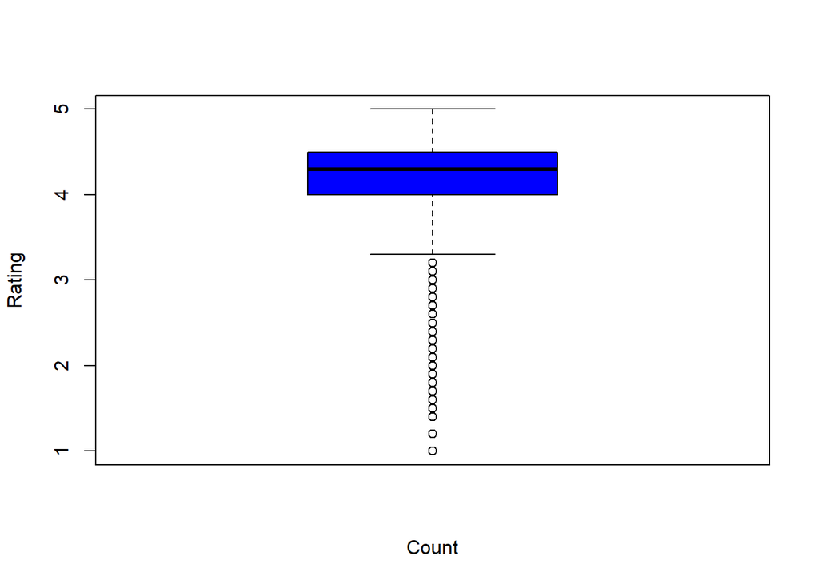

```r
boxplot(data_clean$Rating,ylab = "Rating", xlab = "Count",col = "Blue")
```

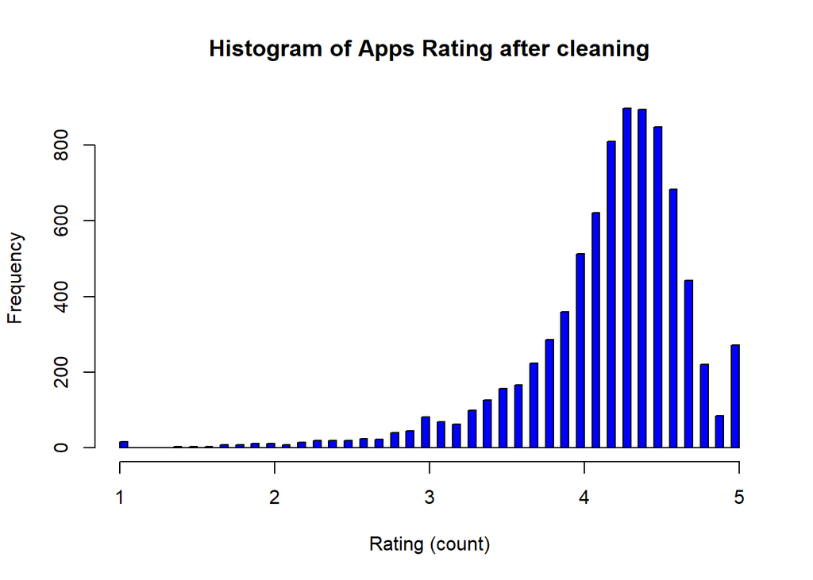

```r
hist(data_clean$Rating, main="Histogram of Apps Rating after cleaning", xlab="Rating (count)", col = 'blue', breaks = 100 )
```

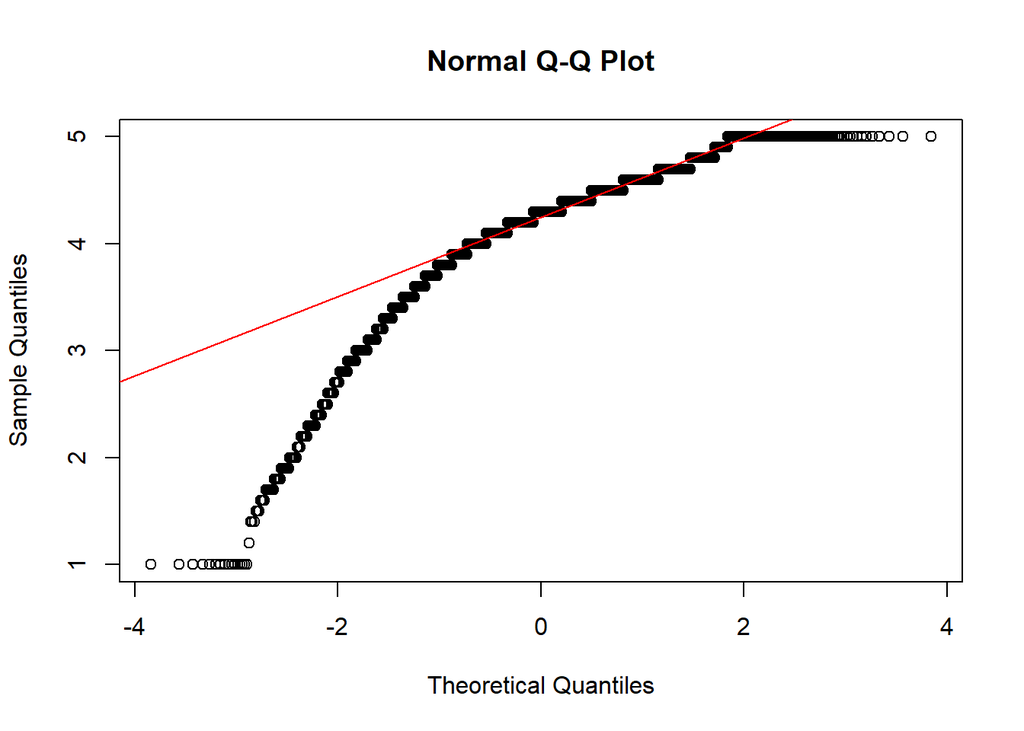

```r
qqnorm(data_clean$Rating)
qqline(data_clean$Rating, col = "red")
```

Here, it could be seen the plots are much clearer but still skewed due to other outliers from 1-3 rating but as these may be the reason from which the low rating could be found these cannot be removed from our dataset

The figure below shows the distribution of NA Ratings by Category.

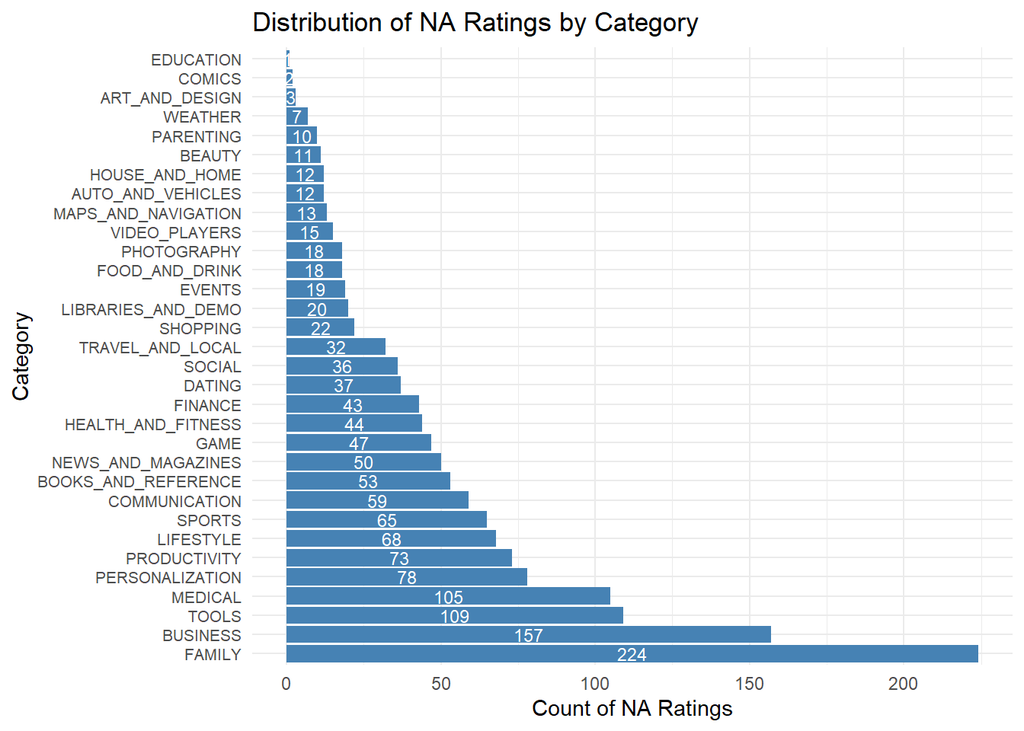

```r
df_na_rating <- data_clean %>% filter(is.na(Rating))

# Group by Category and count the number of NA ratings for each category
na_rating_distribution <- df_na_rating %>%
  group_by(Category) %>%
  summarise(count = n()) %>%
  arrange(desc(count))


ggplot(na_rating_distribution, aes(x = reorder(Category, -count), y = count)) +
  geom_bar(stat = "identity", fill = "steelblue") +
  geom_text(aes(label = count),
            position = position_stack(vjust = 0.5),  # Center the text within the bars
            color = "white", size = 3) +  # Adjust text color and size
  coord_flip() +
  theme_minimal() +
  labs(title = "Distribution of NA Ratings by Category",
       x = "Category",
       y = "Count of NA Ratings") +
  theme(axis.text.y = element_text(size = 8))
```

##Plotting for Reviews

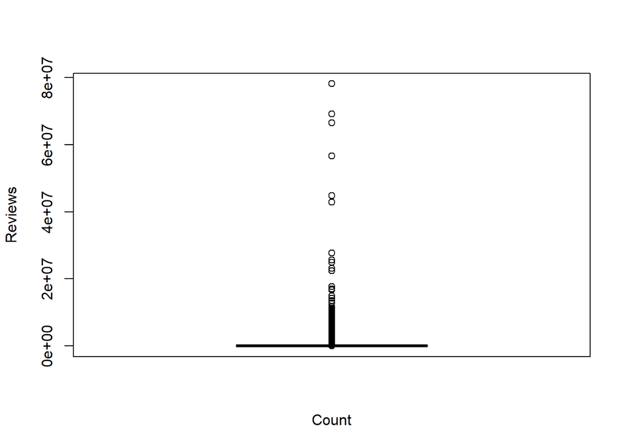

```r
boxplot(data_clean$Reviews,ylab = "Reviews", xlab = "Count",col = 'Blue')
```

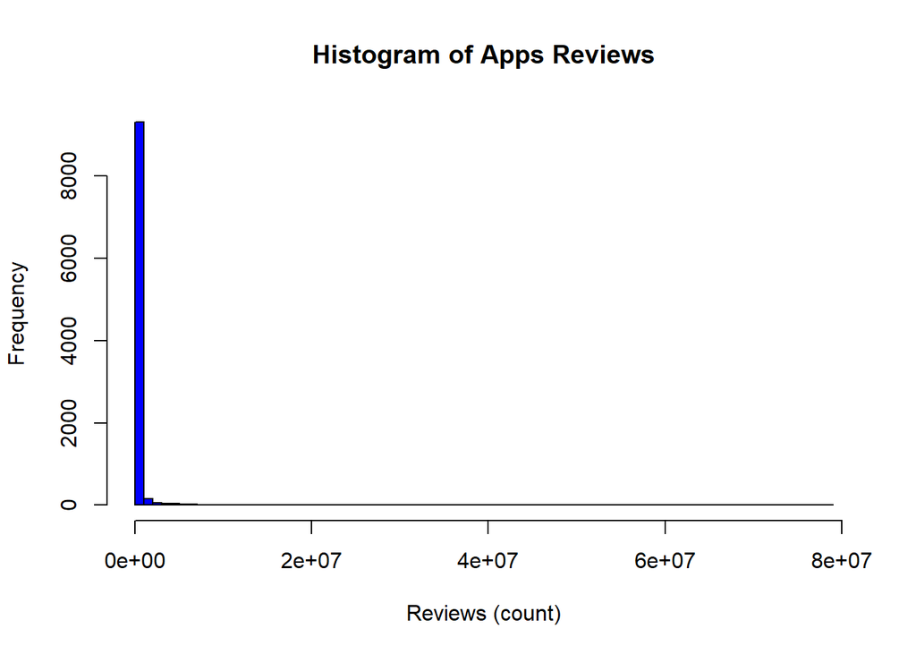

```r
hist(data_clean$Reviews, main="Histogram of Apps Reviews", xlab="Reviews (count)", col = 'blue', breaks = 100 )
```

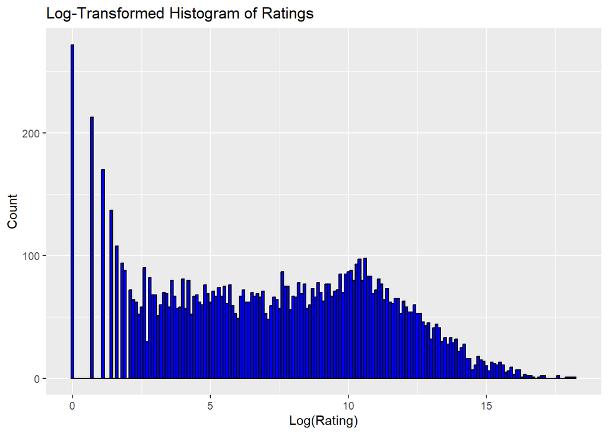

```r
ggplot(data_clean, aes(x = log(Reviews))) +
  geom_histogram(binwidth = 0.1, fill = "blue", color = "black") +
  labs(title = "Log-Transformed Histogram of Ratings", x = "Log(Rating)", y = "Count")
```

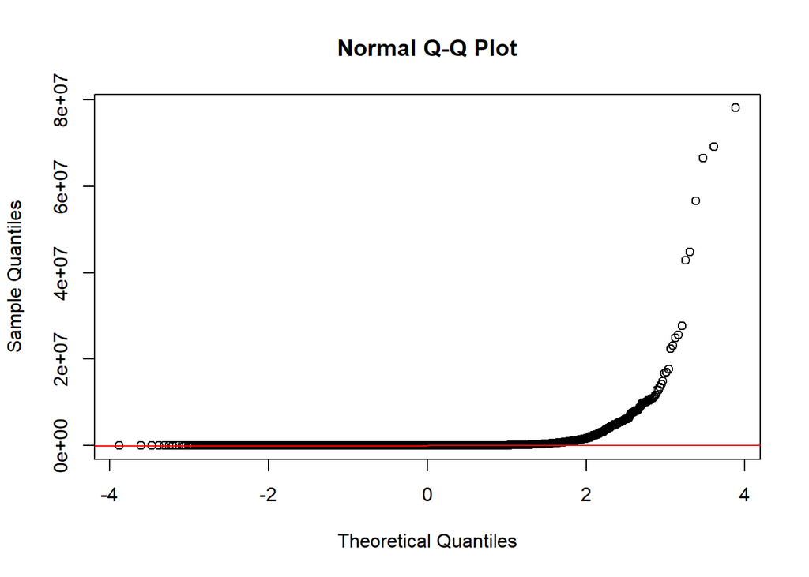

```r
qqnorm(data_clean$Reviews)
qqline(data_clean$Reviews, col = "red")
```

Similar to the case of ratings the plots are skewed due to the outliers lets check the frequency of the reviews

##Review frequency table

```r
frequency_table = table(data_clean$Reviews)
summary(data_clean$Reviews)
```

```
##     Min.  1st Qu.   Median     Mean  3rd Qu.     Max.
##        0       25      967   216593    29401 78158306
```

```r
outlierKD2(data_clean,Reviews)
```

```
## Outliers identified: 1656
## Proportion (%) of outliers: 20.7
## Mean of the outliers: 1228141
## Mean without removing outliers: 216592.6
## Mean if we remove outliers: 7280.61
## Nothing changed
```

[figure not shown]

To check which are outliers lets make sections of data that is create bins to check which bins have maximum data, this would help us see how reviews are distributed

##Binned reviews

```r
# Define the new custom breaks for bins
# Ensure there are no NA values
data_clean1 <- na.omit(data_clean)

# Define new breaks for more even intervals
breaks <- c(0, 500, 1000, 2500, 5000, 10000, 25000,50000,100000, 300000,1000000,Inf)

# Create a categorical variable based on the new breaks
data_clean1$Review_Category <- cut(data_clean1$Reviews, breaks = breaks, right = FALSE,
                   labels = c("Around 500", "Around 1k", " Around 2.5K",
                              "Around 5K", "Around 10K", "Around 25k","Around 50K",
                              "Around 100K", "Around 300K","Around 1M","1M and above"))

# Count the number of values in each bin
bin_counts <- table(data_clean1$Review_Category)

# Print the counts
print(bin_counts)
```

```
##
##   Around 500    Around 1k  Around 2.5K    Around 5K   Around 10K   Around 25k
##         2938          458          583          473          474          719
##   Around 50K  Around 100K  Around 300K    Around 1M 1M and above
##          606          498          647          451          349
```

##Histogram of Review Category with reviews bins

```r
# Assuming 'df' is your dataframe containing the review counts
# Define the custom breaks for bins


# View the dataframe with the new 'review_category' column
head(data_clean1)
```

```
##                                                  App       Category Rating
## 1     Photo Editor & Candy Camera & Grid & ScrapBook ART_AND_DESIGN    4.1
## 2                                Coloring book moana ART_AND_DESIGN    3.9
## 3 U Launcher Lite – FREE Live Cool Themes, Hide Apps ART_AND_DESIGN    4.7
## 4                              Sketch - Draw & Paint ART_AND_DESIGN    4.5
## 5              Pixel Draw - Number Art Coloring Book ART_AND_DESIGN    4.3
## 6                         Paper flowers instructions ART_AND_DESIGN    4.4
##   Reviews Size    Installs Price Content.Rating                    Genres
## 1     159  19M     10,000+     0       Everyone              Art & Design
## 2     967  14M    500,000+     0       Everyone Art & Design;Pretend Play
## 3   87510 8.7M  5,000,000+     0       Everyone              Art & Design
## 4  215644  25M 50,000,000+     0           Teen              Art & Design
## 5     967 2.8M    100,000+     0       Everyone   Art & Design;Creativity
## 6     167 5.6M     50,000+     0       Everyone              Art & Design
##       Last.Updated        Current.Ver  Android.Ver Review_Category
## 1  January 7, 2018              1.0.0 4.0.3 and up      Around 500
## 2 January 15, 2018              2.0.0 4.0.3 and up       Around 1k
## 3   August 1, 2018              1.2.4 4.0.3 and up     Around 100K
## 4     June 8, 2018 Varies with device   4.2 and up     Around 300K
## 5    June 20, 2018                1.1   4.4 and up       Around 1k
## 6   March 26, 2017                1.0   2.3 and up      Around 500
```

```r
summary(data_clean1$Review_Category)
```

```
##   Around 500    Around 1k  Around 2.5K    Around 5K   Around 10K   Around 25k
##         2938          458          583          473          474          719
##   Around 50K  Around 100K  Around 300K    Around 1M 1M and above
##          606          498          647          451          349
```

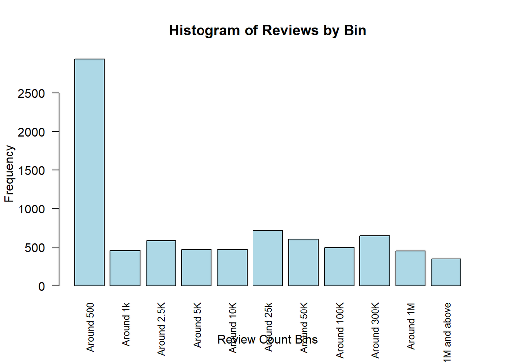

```r
barplot(bin_counts,
        main = "Histogram of Reviews by Bin",
        xlab = "Review Count Bins",
        ylab = "Frequency",
        col = "lightblue",
        border = "black",
        las = 2,  # Make the axis labels perpendicular to the axis
        na.rm = TRUE,
        cex.names = 0.8) #
```

## Rating vs Reviews boxplots

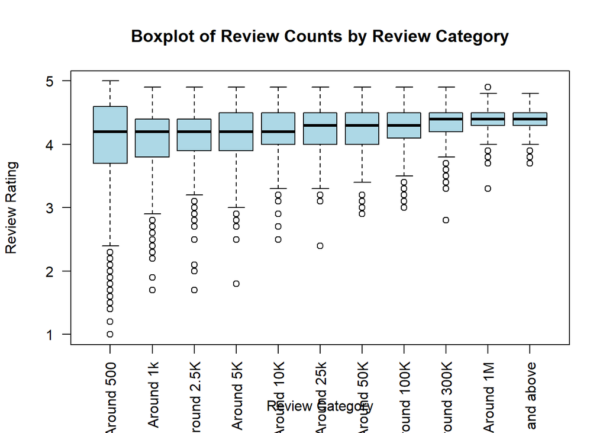

```r
boxplot( data_clean1$Rating~ data_clean1$Review_Category, data = data_clean1,
        main = "Boxplot of Review Counts by Review Category",
        xlab = "Review Category",
        ylab = "Review Rating",
        las = 2,        # Rotate the x-axis labels for readability
        col = "lightblue")  # Optional: Set color for the boxplots
```

## Mean value of Ratings for each Review bins

```r
# Load dplyr package
library(dplyr)

# Group by ReviewCategory and calculate mean Rating
mean_ratings <- data_clean1 %>%
  group_by(Review_Category) %>%
  summarise(mean_rating = mean(Rating, na.rm = TRUE))

# View the result
print(mean_ratings)
```

```
## # A tibble: 11 × 2
##    Review_Category mean_rating
##    <fct>                 <dbl>
##  1 "Around 500"           4.07
##  2 "Around 1k"            4.06
##  3 " Around 2.5K"         4.11
##  4 "Around 5K"            4.13
##  5 "Around 10K"           4.19
##  6 "Around 25k"           4.22
##  7 "Around 50K"           4.23
##  8 "Around 100K"          4.29
##  9 "Around 300K"          4.33
## 10 "Around 1M"            4.38
## 11 "1M and above"         4.43
```

## Plotting of Rating averages in Review Bins

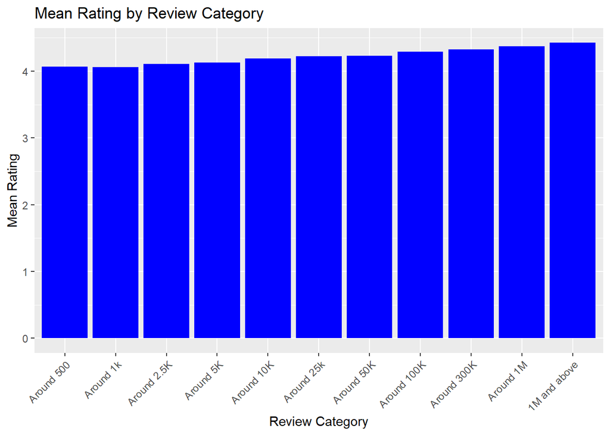

```r
ggplot(mean_ratings, aes(x = Review_Category, y = mean_rating)) +
  geom_bar(stat = "identity", fill = "blue") +
  labs(title = "Mean Rating by Review Category", x = "Review Category", y = "Mean Rating") +
  theme(axis.text.x = element_text(angle = 45, hjust = 1))  # Rotate x-axis labels if needed
```

##Histogram of Reviews and Rating

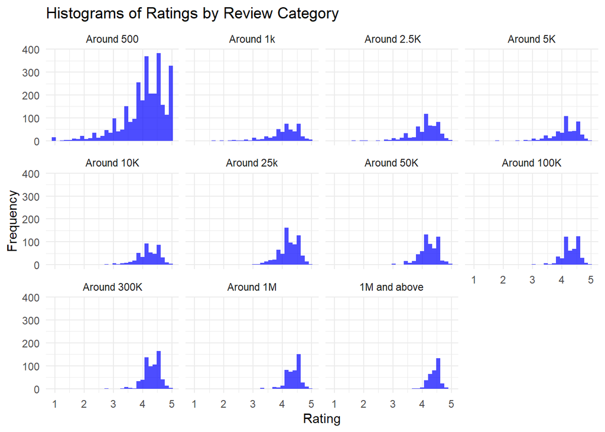

```r
ggplot(data_clean1, aes(x = Rating)) +
    geom_histogram(bins = 30, fill = "blue", alpha = 0.7) +
    facet_wrap(~ Review_Category) +
    theme_minimal() +
    labs(title = "Histograms of Ratings by Review Category", x = "Rating", y = "Frequency")
```

## ANOVA test

The tests below are to test whether or not different categories have different average ratings.

```r
anova_result <- aov(Rating ~ as.factor(Review_Category), data = data_clean1)
summary(anova_result)
```

```
##                              Df Sum Sq Mean Sq F value Pr(>F)
## as.factor(Review_Category)   10  109.6  10.960   39.86 <2e-16 ***
## Residuals                  8185 2250.3   0.275
## ---
## Signif. codes:  0 '***' 0.001 '**' 0.01 '*' 0.05 '.' 0.1 ' ' 1
```

## Post Hoc Test

```r
# Perform Tukey's HSD
tukey_result <- TukeyHSD(anova_result)
tukey_result
```

```
##   Tukey multiple comparisons of means
##     95% family-wise confidence level
##
## Fit: aov(formula = Rating ~ as.factor(Review_Category), data = data_clean1)
##
## $`as.factor(Review_Category)`
##                                   diff          lwr        upr     p adj
## Around 1k-Around 500      -0.005676261 -0.090483456 0.07913093 1.0000000
##  Around 2.5K-Around 500    0.038786201 -0.037752366 0.11532477 0.8690053
## Around 5K-Around 500       0.061483557 -0.022152180 0.14511929 0.3883524
## Around 10K-Around 500      0.123235905  0.039676193 0.20679562 0.0001105
## Around 25k-Around 500      0.153932548  0.083693336 0.22417176 0.0000000
## Around 50K-Around 500      0.163944849  0.088628001 0.23926170 0.0000000
## Around 100K-Around 500     0.225871765  0.144064193 0.30767934 0.0000000
## Around 300K-Around 500     0.261926649  0.188614823 0.33523847 0.0000000
## Around 1M-Around 500       0.307706420  0.222331737 0.39308110 0.0000000
## 1M and above-Around 500    0.358457696  0.262877320 0.45403807 0.0000000
##  Around 2.5K-Around 1k     0.044462463 -0.060943660 0.14986859 0.9581657
## Around 5K-Around 1k        0.067159818 -0.043507408 0.17782704 0.6812180
## Around 10K-Around 1k       0.128912166  0.018302384 0.23952195 0.0081610
## Around 25k-Around 1k       0.159608809  0.058683860 0.26053376 0.0000195
## Around 50K-Around 1k       0.169621111  0.065098739 0.27414348 0.0000097
## Around 100K-Around 1k      0.231548026  0.122255862 0.34084019 0.0000000
## Around 300K-Around 1k      0.267602910  0.164515946 0.37068987 0.0000000
## Around 1M-Around 1k        0.313382682  0.201395472 0.42536989 0.0000000
## 1M and above-Around 1k     0.364133957  0.244184357 0.48408356 0.0000000
## Around 5K- Around 2.5K     0.022697355 -0.081768557 0.12716327 0.9998104
## Around 10K- Around 2.5K    0.084449704 -0.019955354 0.18885476 0.2464718
## Around 25k- Around 2.5K    0.115146346  0.021062674 0.20923002 0.0039512
## Around 50K- Around 2.5K    0.125158648  0.027225925 0.22309137 0.0019431
## Around 100K- Around 2.5K   0.187085564  0.084077460 0.29009367 0.0000003
## Around 300K- Around 2.5K   0.223140448  0.126741203 0.31953969 0.0000000
## Around 1M- Around 2.5K     0.268920219  0.163056972 0.37478347 0.0000000
## 1M and above- Around 2.5K  0.319671495  0.205418273 0.43392472 0.0000000
## Around 10K-Around 5K       0.061752348 -0.047961826 0.17146652 0.7732274
## Around 25k-Around 5K       0.092448991 -0.007493600 0.19239158 0.1000728
## Around 50K-Around 5K       0.102461293 -0.001112846 0.20603543 0.0555107
## Around 100K-Around 5K      0.164388208  0.056002539 0.27277388 0.0000568
## Around 300K-Around 5K      0.200443092  0.098317687 0.30256850 0.0000000
## Around 1M-Around 5K        0.246222864  0.135120158 0.35732557 0.0000000
## 1M and above-Around 5K     0.296974139  0.177849907 0.41609837 0.0000000
## Around 25k-Around 10K      0.030696643 -0.069182337 0.13057562 0.9961632
## Around 50K-Around 10K      0.040708944 -0.062803815 0.14422170 0.9743365
## Around 100K-Around 10K     0.102635860 -0.005691156 0.21096288 0.0820285
## Around 300K-Around 10K     0.138690744  0.036627590 0.24075390 0.0006310
## Around 1M-Around 10K       0.184470516  0.073425028 0.29551600 0.0000049
## 1M and above-Around 10K    0.235221791  0.116150922 0.35429266 0.0000000
## Around 50K-Around 25k      0.010012302 -0.083080194 0.10310480 0.9999998
## Around 100K-Around 25k     0.071939217 -0.026478585 0.17035702 0.3973535
## Around 300K-Around 25k     0.107994101  0.016516187 0.19947202 0.0067949
## Around 1M-Around 25k       0.153773873  0.052371596 0.25517615 0.0000570
## 1M and above-Around 25k    0.204525148  0.094392531 0.31465777 0.0000001
## Around 100K-Around 50K     0.061926916 -0.040176682 0.16403051 0.6819973
## Around 300K-Around 50K     0.097981800  0.002549679 0.19341392 0.0382761
## Around 1M-Around 50K       0.143761571  0.038778227 0.24874492 0.0005422
## 1M and above-Around 50K    0.194512847  0.081074431 0.30795126 0.0000019
## Around 300K-Around 100K    0.036054884 -0.064578812 0.13668858 0.9871023
## Around 1M-Around 100K      0.081834656 -0.027898446 0.19156776 0.3658568
## 1M and above-Around 100K   0.132585931  0.014738041 0.25043382 0.0131430
## Around 1M-Around 300K      0.045779772 -0.057774555 0.14933410 0.9428502
## 1M and above-Around 300K   0.096531047 -0.015586169 0.20864826 0.1690092
## 1M and above-Around 1M     0.050751275 -0.069600223 0.17110277 0.9582520
```

```r
# Convert the result to a data frame
tukey_df <- as.data.frame(tukey_result$`as.factor(Review_Category)`)

# Filter for significant p-values
significant_tukey <- tukey_df[tukey_df[4] < 0.05, ]

# Display the significant results
print(significant_tukey)
```

```
##                                diff         lwr       upr        p adj
## Around 10K-Around 500     0.1232359 0.039676193 0.2067956 1.104846e-04
## Around 25k-Around 500     0.1539325 0.083693336 0.2241718 1.270322e-10
## Around 50K-Around 500     0.1639448 0.088628001 0.2392617 1.683113e-10
## Around 100K-Around 500    0.2258718 0.144064193 0.3076793 2.502198e-11
## Around 300K-Around 500    0.2619266 0.188614823 0.3352385 2.494271e-11
## Around 1M-Around 500      0.3077064 0.222331737 0.3930811 2.494227e-11
## 1M and above-Around 500   0.3584577 0.262877320 0.4540381 2.494227e-11
## Around 10K-Around 1k      0.1289122 0.018302384 0.2395219 8.161023e-03
## Around 25k-Around 1k      0.1596088 0.058683860 0.2605338 1.954935e-05
## Around 50K-Around 1k      0.1696211 0.065098739 0.2741435 9.666520e-06
## Around 100K-Around 1k     0.2315480 0.122255862 0.3408402 5.571765e-10
## Around 300K-Around 1k     0.2676029 0.164515946 0.3706899 2.506106e-11
## Around 1M-Around 1k       0.3133827 0.201395472 0.4253699 2.504164e-11
## 1M and above-Around 1k    0.3641340 0.244184357 0.4840836 2.505551e-11
## Around 25k- Around 2.5K   0.1151463 0.021062674 0.2092300 3.951198e-03
## Around 50K- Around 2.5K   0.1251586 0.027225925 0.2230914 1.943099e-03
## Around 100K- Around 2.5K  0.1870856 0.084077460 0.2900937 2.837042e-07
## Around 300K- Around 2.5K  0.2231404 0.126741203 0.3195397 3.056178e-11
## Around 1M- Around 2.5K    0.2689202 0.163056972 0.3747835 2.509015e-11
## 1M and above- Around 2.5K 0.3196715 0.205418273 0.4339247 2.504152e-11
## Around 100K-Around 5K     0.1643882 0.056002539 0.2727739 5.678905e-05
## Around 300K-Around 5K     0.2004431 0.098317687 0.3025685 1.522372e-08
## Around 1M-Around 5K       0.2462229 0.135120158 0.3573256 8.272139e-11
## 1M and above-Around 5K    0.2969741 0.177849907 0.4160984 2.514933e-11
## Around 300K-Around 10K    0.1386907 0.036627590 0.2407539 6.309792e-04
## Around 1M-Around 10K      0.1844705 0.073425028 0.2955160 4.947479e-06
## 1M and above-Around 10K   0.2352218 0.116150922 0.3542927 1.168303e-08
## Around 300K-Around 25k    0.1079941 0.016516187 0.1994720 6.794896e-03
## Around 1M-Around 25k      0.1537739 0.052371596 0.2551761 5.699384e-05
## 1M and above-Around 25k   0.2045251 0.094392531 0.3146578 1.282019e-07
## Around 300K-Around 50K    0.0979818 0.002549679 0.1934139 3.827614e-02
## Around 1M-Around 50K      0.1437616 0.038778227 0.2487449 5.422064e-04
## 1M and above-Around 50K   0.1945128 0.081074431 0.3079513 1.897173e-06
## 1M and above-Around 100K  0.1325859 0.014738041 0.2504338 1.314299e-02
```

## Category

```r
length(unique(data_clean$Category))
```

```
## [1] 33
```

```r
length(unique(data_clean$Genres))
```

```
## [1] 118
```

Below is the graph for the distribution of Categories for the dataset after removing duplicates.

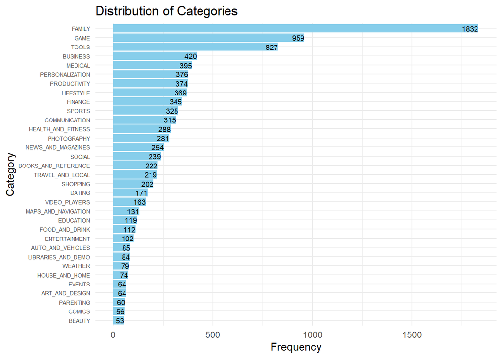

```r
#Distribution for Category
category_counts <- table(data_clean$Category)

# Convert to data frame for plotting
category_counts_df <- as.data.frame(category_counts)
colnames(category_counts_df) <- c("Category", "Frequency")

ggplot(category_counts_df, aes(x = reorder(Category, Frequency), y = Frequency)) +
  geom_bar(stat = "identity", fill = "skyblue") +
  geom_text(aes(label = Frequency), vjust = 0.5, hjust=1, size=2.5) +
  coord_flip() +
  labs(title = "Distribution of Categories", x = "Category", y = "Frequency") +
  theme_minimal() +
  theme(axis.text.y = element_text(size = 5.5))
```

## Current Version

Due to the inconsistent formatting of values in the `Current.Ver` column, it is recommended that this column be excluded from the analysis.

## Android Version

```r
# df_clean <- data_clean %>%
#   mutate(Android_Ver = sapply(Android.Ver, extract_version)) %>%
#   filter(!is.na(Android_Ver))  # Remove rows with NA
#
#
# ggplot(df_clean, aes(x = Android_Ver)) +
#   geom_histogram(binwidth = 0.5, fill = "steelblue", color = "black") +
#   scale_x_continuous(breaks = seq(1, 8, by = 1.0)) +  # Set x-axis ticks from 1.0 to 8.0
#   theme_minimal() +
#   labs(title = "Distribution of Android Versions",
#        x = "Android Version",
#        y = "Count") +
#   theme(axis.text.x = element_text(angle = 45, hjust = 1))
```

The following code contains additional functions, which will be placed in a separate R file to improve the readability and organization of the main R script.

```r
# extract_version <- function(version) {
#   version <- tolower(version)  # Make lowercase for consistency
#
#   # Handle "Varies with device" and "NaN"
#   if (version == "varies with device" || version == "nan") return(NA)
#
#   # Extract the first version in case of ranges (e.g., "4.1 - 7.1.1" -> "4.1")
#   first_version <- strsplit(version, "[- ]")[[1]][1]
#
#   # Remove "and up" if present (e.g., "4.0 and up" -> "4.0")
#   first_version <- gsub("and up", "", first_version)
#
#   return(as.numeric(first_version))  # Convert to numeric
# }
```

```r
print(head(data_clean))
```

```
##                                                  App       Category Rating
## 1     Photo Editor & Candy Camera & Grid & ScrapBook ART_AND_DESIGN    4.1
## 2                                Coloring book moana ART_AND_DESIGN    3.9
## 3 U Launcher Lite – FREE Live Cool Themes, Hide Apps ART_AND_DESIGN    4.7
## 4                              Sketch - Draw & Paint ART_AND_DESIGN    4.5
## 5              Pixel Draw - Number Art Coloring Book ART_AND_DESIGN    4.3
## 6                         Paper flowers instructions ART_AND_DESIGN    4.4
##   Reviews Size    Installs Price Content.Rating                    Genres
## 1     159  19M     10,000+     0       Everyone              Art & Design
## 2     967  14M    500,000+     0       Everyone Art & Design;Pretend Play
## 3   87510 8.7M  5,000,000+     0       Everyone              Art & Design
## 4  215644  25M 50,000,000+     0           Teen              Art & Design
## 5     967 2.8M    100,000+     0       Everyone   Art & Design;Creativity
## 6     167 5.6M     50,000+     0       Everyone              Art & Design
##       Last.Updated        Current.Ver  Android.Ver
## 1  January 7, 2018              1.0.0 4.0.3 and up
## 2 January 15, 2018              2.0.0 4.0.3 and up
## 3   August 1, 2018              1.2.4 4.0.3 and up
## 4     June 8, 2018 Varies with device   4.2 and up
## 5    June 20, 2018                1.1   4.4 and up
## 6   March 26, 2017                1.0   2.3 and up
```

```r
library(ggplot2)
library(dplyr)
library(lubridate)
library(tidyr)
library(scales)
library(cluster)
```

```r
# Remove leading and trailing spaces and convert all text to a consistent format (e.g., title case)
data_clean$Content.Rating <- trimws(tolower(data_clean$Content.Rating))

cr_missing <- sum(is.na(data_clean$`Content Rating`))

print(paste("Number of missing values in 'Content Rating':", cr_missing))
```

```
## [1] "Number of missing values in 'Content Rating': 0"
```

```r
# Check for null/missing values
# Convert Last Updated to Date format
data_clean$Last.Updated <- as.Date(data_clean$Last.Updated, format = "%B %d, %Y")

# Verify the cleaning
print("\nSummary of Last.Updated after cleaning:")
```

```
## [1] "\nSummary of Last.Updated after cleaning:"
```

```r
print(summary(data_clean$Last.Updated))
```

```
##         Min.      1st Qu.       Median         Mean      3rd Qu.         Max.
## "2010-05-21" "2017-08-05" "2018-05-04" "2017-10-30" "2018-07-17" "2018-08-08"
```

```r
# 1. Content Rating Distribution
content_rating_dist <- table(data_clean$Content.Rating)
print("Content Rating Distribution:")
```

```
## [1] "Content Rating Distribution:"
```

```r
print(content_rating_dist)
```

```
##
## adults only 18+        everyone    everyone 10+      mature 17+            teen
##               3            7903             322             393            1036
##         unrated
##               2
```

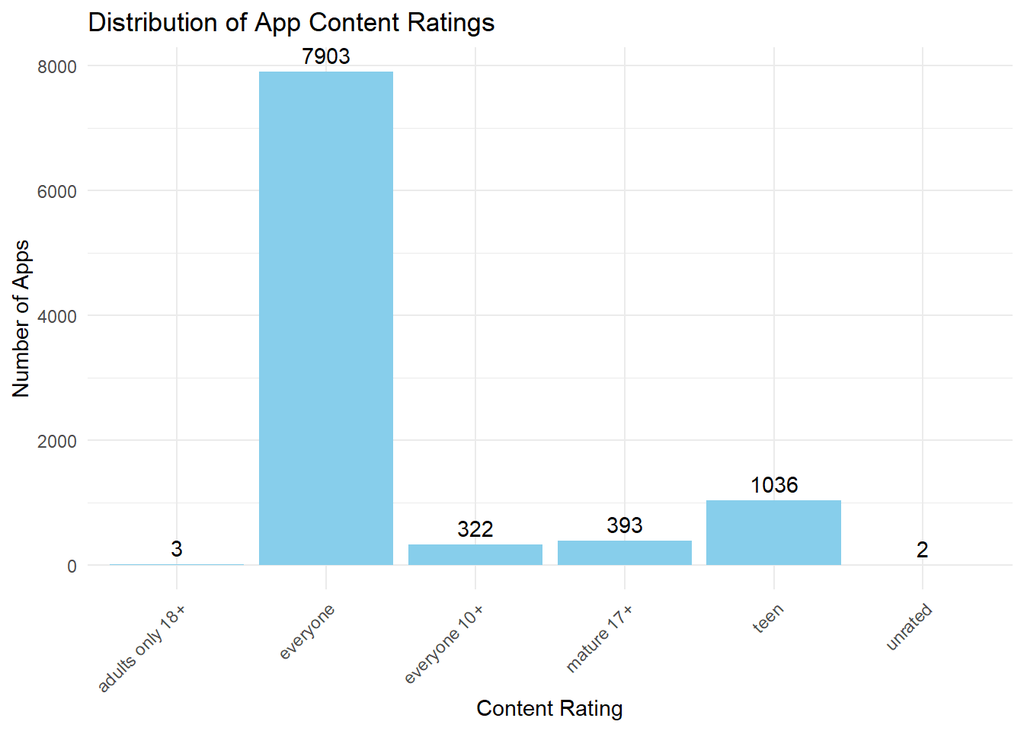

```r
# Bar plot for Content Rating
ggplot(data_clean, aes(x = Content.Rating)) +
  geom_bar(fill = "skyblue") +
  geom_text(stat = "count", aes(label = ..count..), vjust = -0.5) +
  labs(title = "Distribution of App Content Ratings",
       x = "Content Rating",
       y = "Number of Apps") +
  theme_minimal() +
  theme(axis.text.x = element_text(angle = 45, hjust = 1))
```

Frequency of different content ratings assigned to a set of apps, each bar represents the count of apps for a specific content rating category

```r
# Last Updated Analysis

# Create summary of updates by month and year
updates_by_month <- data_clean %>%
  mutate(
    update_month = format(Last.Updated, "%Y-%m"),
    update_year = year(Last.Updated)
  ) %>%
  group_by(update_month) %>%
  summarize(count = n()) %>%
  arrange(update_month)
```

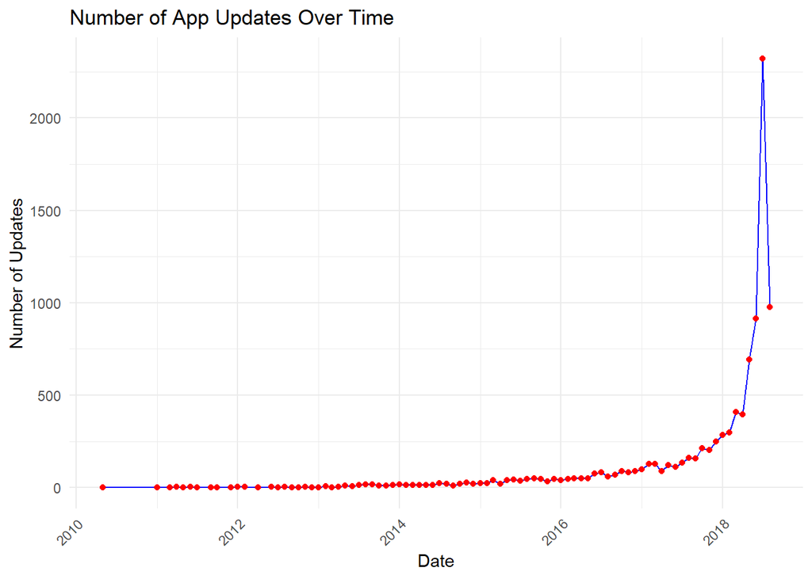

```r
# Plot updates over time
ggplot(updates_by_month, aes(x = as.Date(paste0(update_month, "-01")), y = count)) +
  geom_line(color = "blue") +
  geom_point(color = "red") +
  labs(title = "Number of App Updates Over Time",
       x = "Date",
       y = "Number of Updates") +
  theme_minimal() +
  theme(axis.text.x = element_text(angle = 45, hjust = 1))
```

The number of updates have drastically increased from the end of 2017

```r
# Content Rating and Update Frequency Relationship
update_frequency_by_rating <- data_clean %>%
  group_by(Content.Rating) %>%
  summarize(
    avg_last_update = mean(Last.Updated),
    median_last_update = median(Last.Updated),
    n_apps = n()
  )
print("\nUpdate Frequency by Content Rating:")
```

```
## [1] "\nUpdate Frequency by Content Rating:"
```

```r
print(update_frequency_by_rating)
```

```
## # A tibble: 6 × 4
##   Content.Rating  avg_last_update median_last_update n_apps
##   <chr>           <date>          <date>              <int>
## 1 adults only 18+ 2018-07-20      2018-07-24              3
## 2 everyone        2017-10-20      2018-04-20           7903
## 3 everyone 10+    2017-11-24      2018-06-06            322
## 4 mature 17+      2018-02-18      2018-07-09            393
## 5 teen            2017-12-03      2018-06-05           1036
## 6 unrated         2013-10-25      2013-10-25              2
```

```r
# Chi-square test for independence
# Creating contingency table of Content Rating vs Update Year
content_update_table <- table(
  data_clean$Content.Rating,
  year(data_clean$Last.Updated)
)
chi_test <- chisq.test(content_update_table)
print("\nChi-square test results:")
```

```
## [1] "\nChi-square test results:"
```

```r
print(chi_test)
```

```
##
##  Pearson's Chi-squared test
##
## data:  content_update_table
## X-squared = 266.64, df = 40, p-value < 2.2e-16
```

The P value is small signifying that there is statistically significant relationship between Content Rating and Last Updated Columns

```r
# Content Rating Basic Analysis
print("Basic Content Rating Analysis:")
```

```
## [1] "Basic Content Rating Analysis:"
```

```r
content_rating_counts <- table(data_clean$Content.Rating)
print(content_rating_counts)
```

```
##
## adults only 18+        everyone    everyone 10+      mature 17+            teen
##               3            7903             322             393            1036
##         unrated
##               2
```

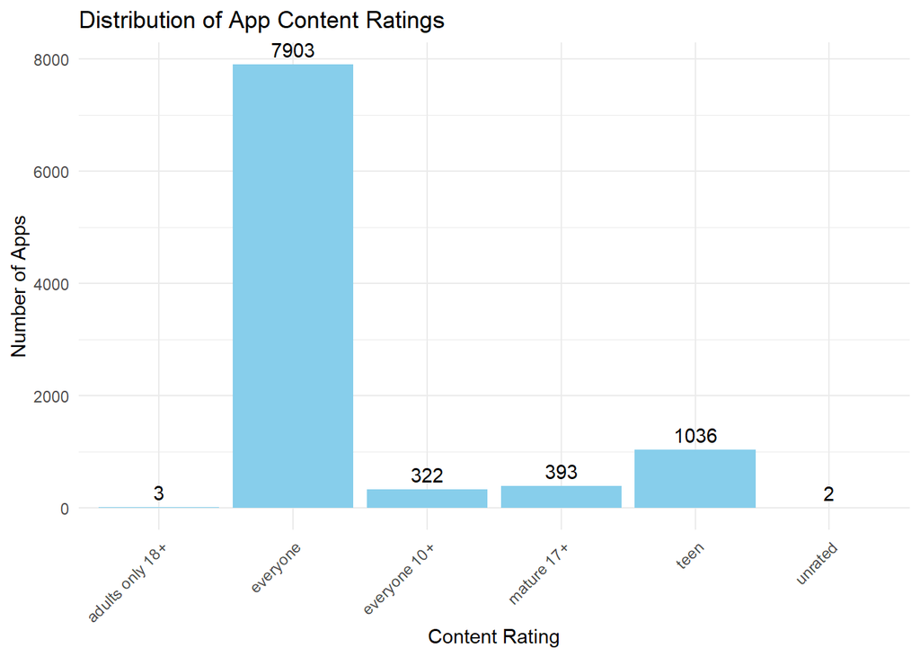

```r
# Basic bar plot for Content Rating
ggplot(data_clean, aes(x = Content.Rating)) +
  geom_bar(fill = "skyblue") +
  geom_text(stat = "count", aes(label = ..count..), vjust = -0.5) +
  labs(title = "Distribution of App Content Ratings",
       x = "Content Rating",
       y = "Number of Apps") +
  theme_minimal() +
  theme(axis.text.x = element_text(angle = 45, hjust = 1))
```

```r
# Calculate percentages
content_rating_percentages <- prop.table(content_rating_counts) * 100
print("\nContent Rating Percentages:")
```

```
## [1] "\nContent Rating Percentages:"
```

```r
print(round(content_rating_percentages, 2))
```

```
##
## adults only 18+        everyone    everyone 10+      mature 17+            teen
##            0.03           81.82            3.33            4.07           10.73
##         unrated
##            0.02
```

```r
# 1.2 Last Updated Basic Analysis
data_clean$Last.Updated <- as.Date(data_clean$Last.Updated, format = "%B %d, %Y")

print("\nLast Updated Summary Statistics:")
```

```
## [1] "\nLast Updated Summary Statistics:"
```

```r
summary(data_clean$Last.Updated)
```

```
##         Min.      1st Qu.       Median         Mean      3rd Qu.         Max.
## "2010-05-21" "2017-08-05" "2018-05-04" "2017-10-30" "2018-07-17" "2018-08-08"
```

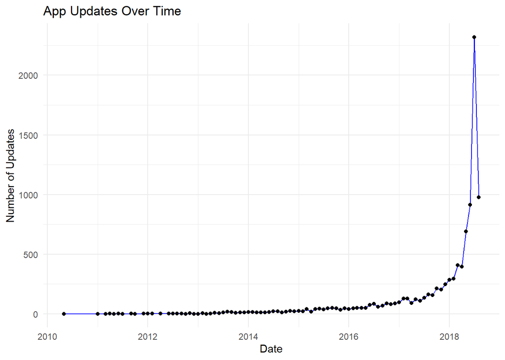

```r
# Time-based Analysis
data_clean <- data_clean %>%
  mutate(
    update_year = year(Last.Updated),
    update_month = month(Last.Updated),
    update_quarter = quarter(Last.Updated),
    days_since_update = as.numeric(difftime(max(Last.Updated), Last.Updated, units = "days"))
  )

# Monthly update pattern
monthly_updates <- data_clean %>%
  group_by(update_year, update_month) %>%
  summarize(count = n()) %>%
  mutate(date = as.Date(paste(update_year, update_month, "01", sep = "-")))

ggplot(monthly_updates, aes(x = date, y = count)) +
  geom_line(color = "blue") +
  geom_point() +
  labs(title = "App Updates Over Time",
       x = "Date",
       y = "Number of Updates") +
  theme_minimal()
```

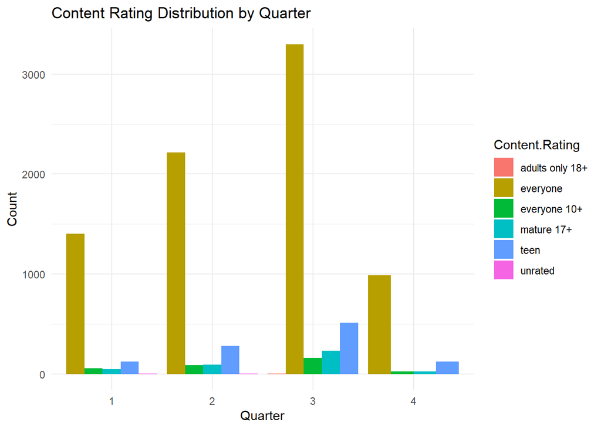

```r
# 2.2 Content Rating Distribution by Update Quarter
ggplot(data_clean, aes(x = factor(update_quarter), fill = Content.Rating)) +
  geom_bar(position = "dodge") +
  labs(title = "Content Rating Distribution by Quarter",
       x = "Quarter",
       y = "Count") +
  theme_minimal()
```

```r
# 3.1 Update Frequency Analysis by Content Rating
update_patterns <- data_clean %>%
  group_by(Content.Rating) %>%
  summarize(
    avg_days_since_update = mean(days_since_update),
    median_days_since_update = median(days_since_update),
    sd_days_since_update = sd(days_since_update),
    n_apps = n()
  ) %>%
  arrange(avg_days_since_update)

print("\nUpdate Patterns by Content Rating:")
```

```
## [1] "\nUpdate Patterns by Content Rating:"
```

```r
print(update_patterns)
```

```
## # A tibble: 6 × 5
##   Content.Rating  avg_days_since_update median_days_since_update
##   <chr>                           <dbl>                    <dbl>
## 1 adults only 18+                  18.3                      15
## 2 mature 17+                      171.                       30
## 3 teen                            248.                       64
## 4 everyone 10+                    257.                       63
## 5 everyone                        292.                      110
## 6 unrated                        1748.                     1748.
## # ℹ 2 more variables: sd_days_since_update <dbl>, n_apps <int>
```

```r
# 3.2 Statistical Tests

# Chi-square test for independence
contingency_table <- table(data_clean$Content.Rating, data_clean$update_quarter)
chi_test <- chisq.test(contingency_table)
print("\nChi-square test for independence between Content Rating and Update Quarter:")
```

```
## [1] "\nChi-square test for independence between Content Rating and Update Quarter:"
```

```r
print(chi_test)
```

```
##
##  Pearson's Chi-squared test
##
## data:  contingency_table
## X-squared = 88.112, df = 15, p-value = 2.229e-12
```

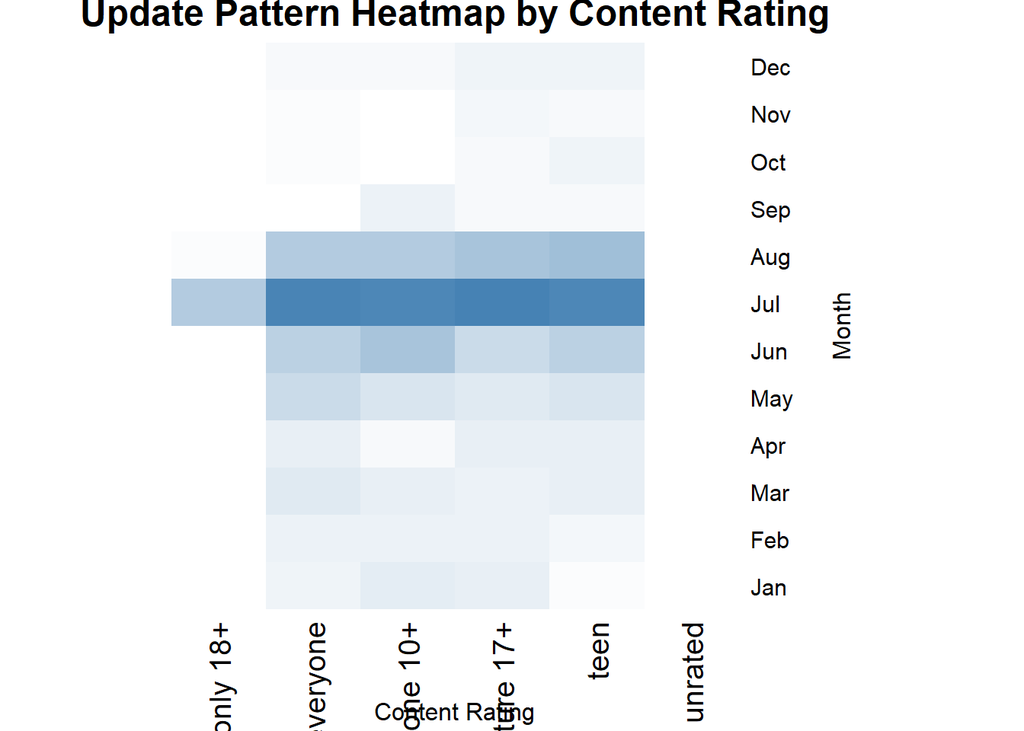

```r
# 3.3 Advanced Visualization - Heatmap of Updates
update_heatmap_data <- data_clean %>%
  group_by(update_month, Content.Rating) %>%
  summarize(count = n()) %>%
  spread(Content.Rating, count)

# Convert to matrix for heatmap
update_matrix <- as.matrix(update_heatmap_data[,-1])
rownames(update_matrix) <- month.abb[update_heatmap_data$update_month]

# Create heatmap
heatmap(update_matrix,
        Colv = NA,
        Rowv = NA,
        scale = "column",
        col = colorRampPalette(c("white", "steelblue"))(50),
        main = "Update Pattern Heatmap by Content Rating",
        xlab = "Content Rating",
        ylab = "Month")
```

[figure not shown]

```r
# 3.4 Time Series Decomposition
# Focus on Everyone category as an example
everyone_ts <- monthly_updates %>%
  filter(count > 0) %>%
  select(count) %>%
  ts(frequency = 12)

decomposed <- decompose(everyone_ts)
plot(decomposed)
```

```r
# 3.5 Update Velocity Analysis
update_velocity <- data_clean %>%
  group_by(Content.Rating) %>%
  summarize(
    update_velocity = n() / n_distinct(update_month),
    total_apps = n()
  ) %>%
  arrange(desc(update_velocity))

print("\nUpdate Velocity by Content Rating:")
```

```
## [1] "\nUpdate Velocity by Content Rating:"
```

```r
print(update_velocity)
```

```
## # A tibble: 6 × 3
##   Content.Rating  update_velocity total_apps
##   <chr>                     <dbl>      <int>
## 1 everyone                  659.        7903
## 2 teen                       86.3       1036
## 3 mature 17+                 32.8        393
## 4 everyone 10+               26.8        322
## 5 adults only 18+             1.5          3
## 6 unrated                     1            2
```

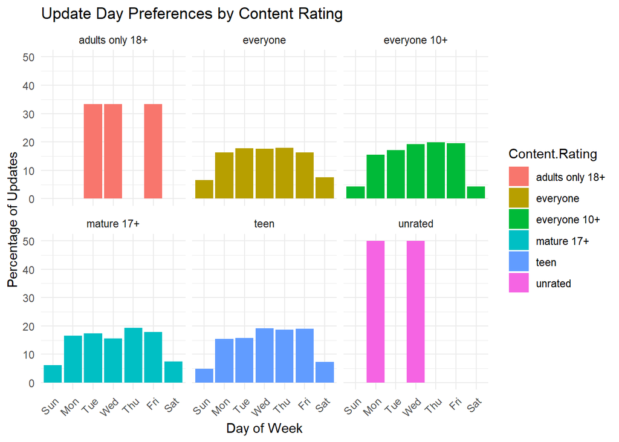

```r
# 1. Update Cycle Analysis
data_clean <- data_clean %>%
  mutate(
    Last.Updated = as.Date(Last.Updated, format = "%B %d, %Y"),
    day_of_week = wday(Last.Updated, label = TRUE),
    week_of_year = week(Last.Updated),
    month_of_year = month(Last.Updated, label = TRUE),
    season = case_when(
      month_of_year %in% c("Dec", "Jan", "Feb") ~ "Winter",
      month_of_year %in% c("Mar", "Apr", "May") ~ "Spring",
      month_of_year %in% c("Jun", "Jul", "Aug") ~ "Summer",
      TRUE ~ "Fall"
    )
  )

# Day of Week Update Pattern by Content Rating
dow_pattern <- data_clean %>%
  group_by(Content.Rating, day_of_week) %>%
  summarise(count = n()) %>%
  group_by(Content.Rating) %>%
  mutate(percentage = count/sum(count) * 100)

ggplot(dow_pattern, aes(x = day_of_week, y = percentage, fill = Content.Rating)) +
  geom_bar(stat = "identity", position = "dodge") +
  facet_wrap(~Content.Rating) +
  labs(title = "Update Day Preferences by Content Rating",
       x = "Day of Week",
       y = "Percentage of Updates") +
  theme_minimal() +
  theme(axis.text.x = element_text(angle = 45, hjust = 1))
```

```r
# 2. Update Interval Analysis
update_intervals <- data_clean %>%
  group_by(Content.Rating) %>%
  arrange(Last.Updated) %>%
  mutate(days_between_updates = as.numeric(Last.Updated - lag(Last.Updated))) %>%
  summarise(
    mean_interval = mean(days_between_updates, na.rm = TRUE),
    median_interval = median(days_between_updates, na.rm = TRUE),
    std_dev = sd(days_between_updates, na.rm = TRUE),
    cv = std_dev / mean_interval * 100  # Coefficient of Variation
  )

print("Update Interval Analysis:")
```

```
## [1] "Update Interval Analysis:"
```

```r
print(update_intervals)
```

```
## # A tibble: 6 × 5
##   Content.Rating  mean_interval median_interval std_dev    cv
##   <chr>                   <dbl>           <dbl>   <dbl> <dbl>
## 1 adults only 18+        15                  15    7.07  47.1
## 2 everyone                0.380               0    3.53 929.
## 3 everyone 10+            8.33                1   46.5  557.
## 4 mature 17+              5.48                0   21.5  392.
## 5 teen                    2.36                0   14.7  622.
## 6 unrated              1213                1213   NA     NA
```

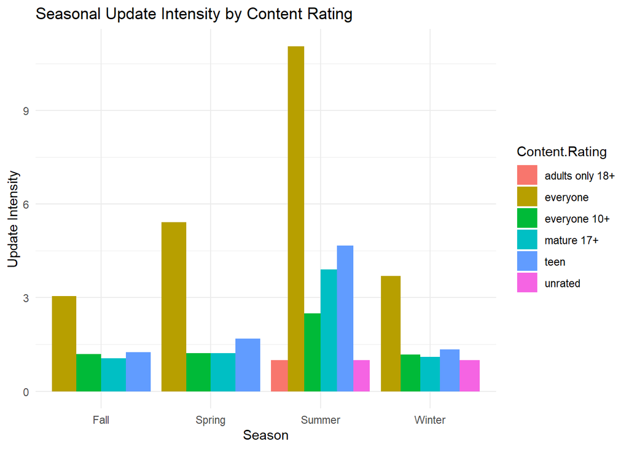

```r
# 3. Seasonal Update Intensity
seasonal_intensity <- data_clean %>%
  group_by(Content.Rating, season) %>%
  summarise(
    update_count = n(),
    update_intensity = n() / n_distinct(Last.Updated)
  ) %>%
  arrange(Content.Rating, desc(update_intensity))

# Visualization of seasonal patterns
ggplot(seasonal_intensity, aes(x = season, y = update_intensity, fill = Content.Rating)) +
  geom_bar(stat = "identity", position = "dodge") +
  labs(title = "Seasonal Update Intensity by Content Rating",
       x = "Season",
       y = "Update Intensity") +
  theme_minimal()
```

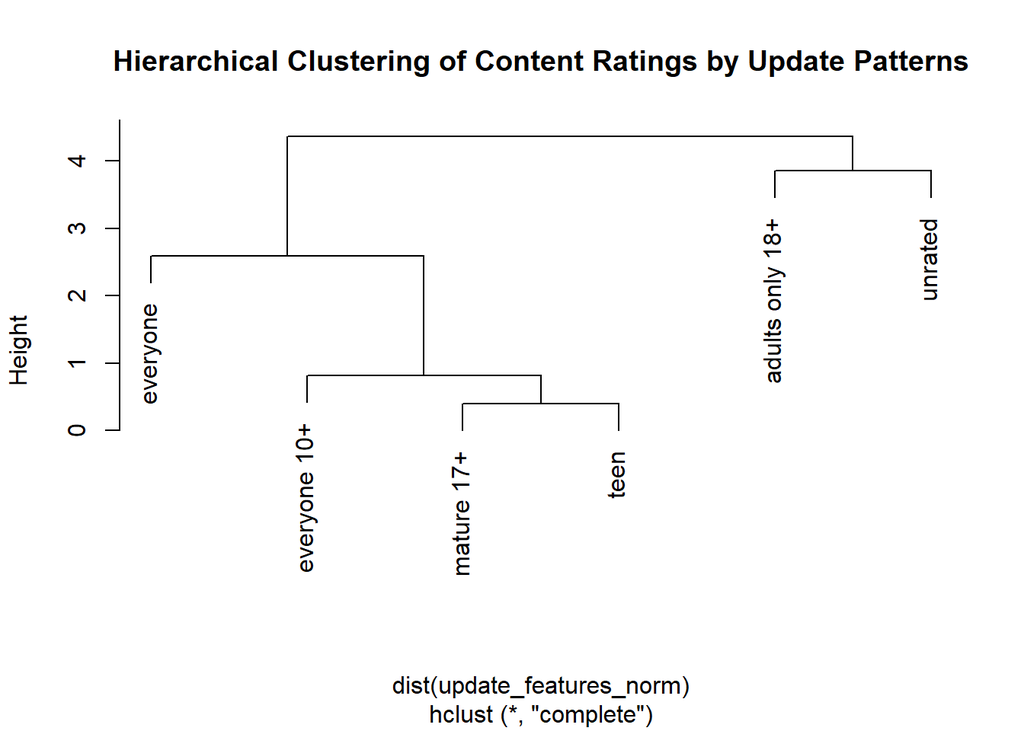

```r
# 4. Update Clustering Analysis
update_features <- data_clean %>%
  group_by(Content.Rating) %>%
  summarise(
    mean_week = mean(week_of_year),
    std_week = sd(week_of_year),
    update_frequency = n(),
    weekend_ratio = sum(day_of_week %in% c("Sat", "Sun")) / n()
  )

# Normalize the features
update_features_norm <- scale(update_features[,-1])
rownames(update_features_norm) <- update_features$Content.Rating

# Perform hierarchical clustering
update_clusters <- hclust(dist(update_features_norm))
plot(update_clusters, main = "Hierarchical Clustering of Content Ratings by Update Patterns")
```

```r
# 6. Update Consistency Score
consistency_score <- data_clean %>%
  group_by(Content.Rating) %>%
  summarise(
    total_updates = n(),
    unique_days = n_distinct(Last.Updated),
    consistency_score = (total_updates / unique_days) *
      (1 - sd(as.numeric(day_of_week)) / 7)  # Normalized consistency metric
  ) %>%
  arrange(desc(consistency_score))

print("\nUpdate Consistency Scores:")
```

```
## [1] "\nUpdate Consistency Scores:"
```

```r
print(consistency_score)
```

```
## # A tibble: 6 × 4
##   Content.Rating  total_updates unique_days consistency_score
##   <chr>                   <int>       <int>             <dbl>
## 1 everyone                 7903        1312             4.55
## 2 teen                     1036         421             1.87
## 3 mature 17+                393         177             1.68
## 4 everyone 10+              322         186             1.34
## 5 unrated                     2           2             0.798
## 6 adults only 18+             3           3             0.782
```

```r
# Convert Last.Updated to numeric (days since reference date) if not already done
reference_date <- min(data_clean$Last.Updated, na.rm = TRUE)  # Reference date
data_clean$Days.Since.Update <- as.numeric(data_clean$Last.Updated - reference_date)

# Perform the Kolmogorov-Smirnov test on the numeric 'Days.Since.Update' values
content_ratings <- unique(data_clean$Content.Rating)
ks_results <- data.frame(
  rating1 = character(),
  rating2 = character(),
  p_value = numeric()
)

for (i in 1:(length(content_ratings)-1)) {
  for (j in (i+1):length(content_ratings)) {
    # Extract groups, removing NA values
    group1 <- na.omit(data_clean$Days.Since.Update[data_clean$Content.Rating == content_ratings[i]])
    group2 <- na.omit(data_clean$Days.Since.Update[data_clean$Content.Rating == content_ratings[j]])

    # Check if both groups have enough data for comparison
    if(length(group1) > 1 && length(group2) > 1) {
      ks_test <- ks.test(group1, group2)
      ks_results <- rbind(ks_results,
                          data.frame(rating1 = content_ratings[i],
                                     rating2 = content_ratings[j],
                                     p_value = ks_test$p.value))
    }
  }
}

print("\nKolmogorov-Smirnov Test Results:")
```

```
## [1] "\nKolmogorov-Smirnov Test Results:"
```

```r
print(ks_results[ks_results$p_value < 0.05,])
```

```
##         rating1      rating2      p_value
## 1      everyone         teen 6.633847e-10
## 2      everyone everyone 10+ 3.881533e-04
## 3      everyone   mature 17+ 7.879731e-22
## 7          teen   mature 17+ 9.690771e-07
## 9          teen      unrated 3.996633e-03
## 10 everyone 10+   mature 17+ 6.198158e-05
## 12 everyone 10+      unrated 2.427092e-03
## 14   mature 17+      unrated 1.580672e-03
```

```r
# Clean and prepare the Installs column
data_clean <- data_clean %>%
  mutate(
    # Remove '+' and ',' from Installs and convert to numeric
    Installs = as.numeric(gsub("[+,]", "", Installs)),
    # Convert Last.Updated to Date format if not already
    Last.Updated = as.Date(Last.Updated, format = "%B %d, %Y"),
    # Convert Content.Rating to factor
    Content.Rating = as.factor(Content.Rating)
  )
```

```r
# 1. Basic statistics for Installs by Content Rating
installs_by_rating <- data_clean %>%
  group_by(Content.Rating) %>%
  summarise(
    mean_installs = mean(Installs, na.rm = TRUE),
    median_installs = median(Installs, na.rm = TRUE),
    total_installs = sum(Installs, na.rm = TRUE),
    n_apps = n()
  ) %>%
  arrange(desc(mean_installs))

print("Summary of Installs by Content Rating:")
```

```
## [1] "Summary of Installs by Content Rating:"
```

```r
print(installs_by_rating)
```

```
## # A tibble: 6 × 5
##   Content.Rating  mean_installs median_installs total_installs n_apps
##   <fct>                   <dbl>           <dbl>          <dbl>  <int>
## 1 teen                15914358.          500000    16487275393   1036
## 2 everyone 10+        12472894.         1000000     4016271795    322
## 3 everyone             6602474.           50000    52179352961   7903
## 4 mature 17+           6203529.          500000     2437986878    393
## 5 adults only 18+       666667.          500000        2000000      3
## 6 unrated                25250            25250          50500      2
```

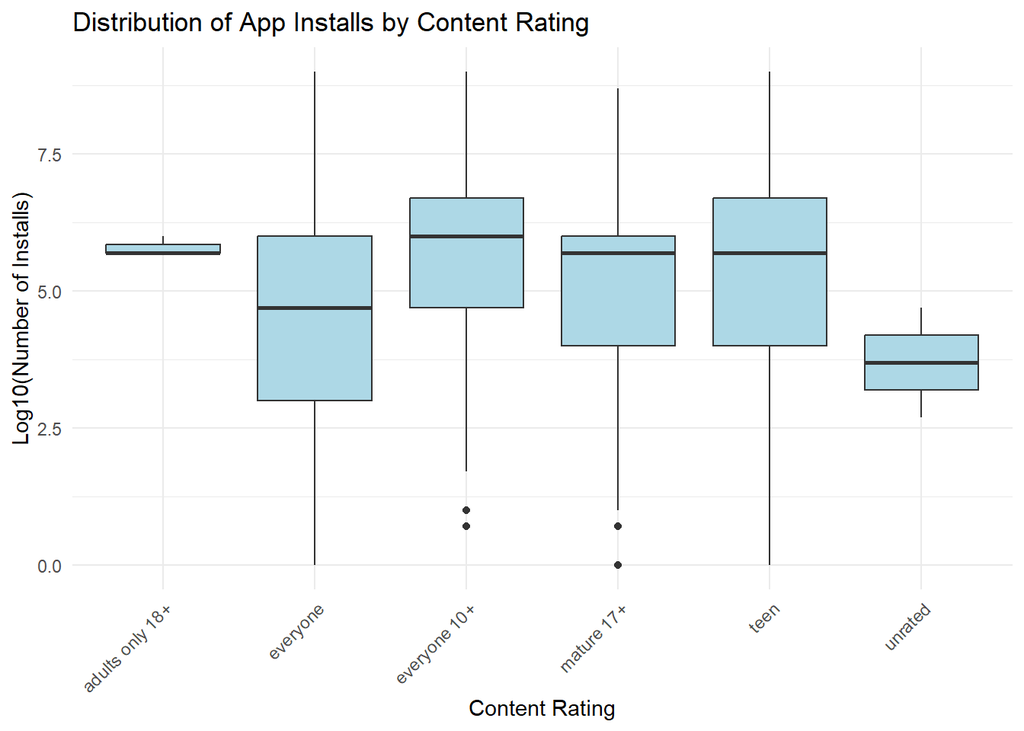

```r
# 2. Visualize distribution of installs by content rating
ggplot(data_clean, aes(x = Content.Rating, y = log10(Installs))) +
  geom_boxplot(fill = "lightblue") +
  labs(title = "Distribution of App Installs by Content Rating",
       x = "Content Rating",
       y = "Log10(Number of Installs)") +
  theme_minimal() +
  theme(axis.text.x = element_text(angle = 45, hjust = 1))
```

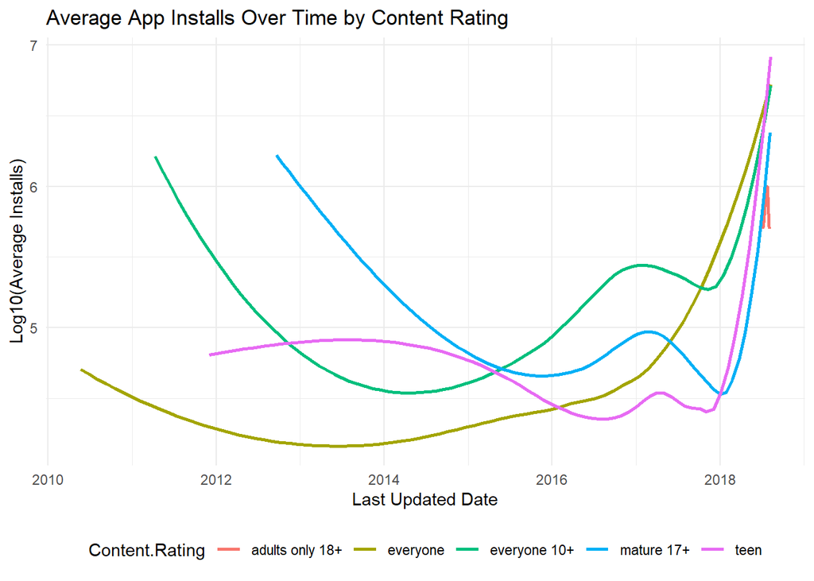

```r
# 3. Timeline analysis: Average installs over time by content rating
installs_timeline <- data_clean %>%
  group_by(Content.Rating, Last.Updated) %>%
  summarise(avg_installs = mean(Installs, na.rm = TRUE)) %>%
  ungroup()

ggplot(installs_timeline, aes(x = Last.Updated, y = log10(avg_installs), color = Content.Rating)) +
  geom_smooth(method = "loess", se = FALSE) +
  labs(title = "Average App Installs Over Time by Content Rating",
       x = "Last Updated Date",
       y = "Log10(Average Installs)") +
  theme_minimal() +
  theme(legend.position = "bottom")
```

```r
# Remove rows where Installs has NA, NaN, or non-positive values (because log10 of 0 or negative is undefined)
data_clean <- data_clean %>%
  filter(!is.na(Installs) & Installs > 0)

# ANOVA test for difference in installs between content ratings
install_anova <- aov(log10(Installs) ~ Content.Rating, data = data_clean)

print("\nANOVA test results for Installs by Content Rating:")
```

```
## [1] "\nANOVA test results for Installs by Content Rating:"
```

```r
print(summary(install_anova))
```

```
##                  Df Sum Sq Mean Sq F value Pr(>F)
## Content.Rating    5    743  148.68   41.95 <2e-16 ***
## Residuals      9638  34160    3.54
## ---
## Signif. codes:  0 '***' 0.001 '**' 0.01 '*' 0.05 '.' 0.1 ' ' 1
```

```r
# 5. Create time-based features for correlation analysis
data_analysis <- data_clean %>%
  mutate(
    days_since_update = as.numeric(difftime(max(Last.Updated), Last.Updated, units = "days")),
    update_year = year(Last.Updated),
    update_month = month(Last.Updated)
  )

# Calculate correlation between days since update and installs
correlation_result <- cor.test(data_analysis$days_since_update,
                             log10(data_analysis$Installs),
                             method = "spearman")

print("\nCorrelation between days since update and installs:")
```

```
## [1] "\nCorrelation between days since update and installs:"
```

```r
print(correlation_result)
```

```
##
##  Spearman's rank correlation rho
##
## data:  data_analysis$days_since_update and log10(data_analysis$Installs)
## S = 1.9908e+11, p-value < 2.2e-16
## alternative hypothesis: true rho is not equal to 0
## sample estimates:
##        rho
## -0.3317186
```

```r
# 6. Recent vs Old updates comparison
data_analysis <- data_analysis %>%
  mutate(update_recency = ifelse(days_since_update <= median(days_since_update),
                                "Recent Update", "Old Update"))

recent_vs_old <- data_analysis %>%
  group_by(Content.Rating, update_recency) %>%
  summarise(
    mean_installs = mean(Installs, na.rm = TRUE),
    median_installs = median(Installs, na.rm = TRUE),
    n_apps = n()
  )

print("\nComparison of Installs by Update Recency and Content Rating:")
```

```
## [1] "\nComparison of Installs by Update Recency and Content Rating:"
```

```r
print(recent_vs_old)
```

```
## # A tibble: 10 × 5
## # Groups:   Content.Rating [6]
##    Content.Rating  update_recency mean_installs median_installs n_apps
##    <fct>           <chr>                  <dbl>           <dbl>  <int>
##  1 adults only 18+ Recent Update        666667.          500000      3
##  2 everyone        Old Update          1789247.           10000   4121
##  3 everyone        Recent Update      11884845.          500000   3770
##  4 everyone 10+    Old Update          2744542.          100000    137
##  5 everyone 10+    Recent Update      19784074.         1000000    184
##  6 mature 17+      Old Update           868289.          100000    119
##  7 mature 17+      Recent Update       8520659.          500000    274
##  8 teen            Old Update          1622749.           50000    443
##  9 teen            Recent Update      26680876.         1000000    591
## 10 unrated         Old Update            25250            25250      2
```

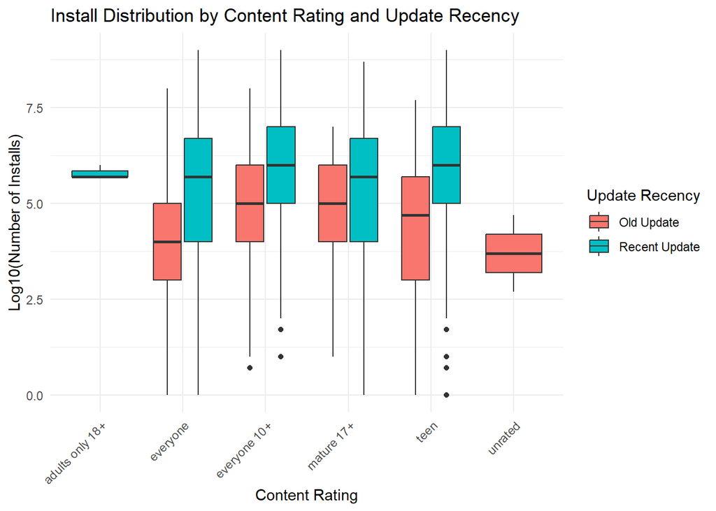

```r
# 7. Visualization of update recency effect
ggplot(data_analysis, aes(x = Content.Rating, y = log10(Installs), fill = update_recency)) +
  geom_boxplot() +
  labs(title = "Install Distribution by Content Rating and Update Recency",
       x = "Content Rating",
       y = "Log10(Number of Installs)",
       fill = "Update Recency") +
  theme_minimal() +
  theme(axis.text.x = element_text(angle = 45, hjust = 1))
```

```r
# 1. Encode content rating (e.g., as factor levels or one-hot encoding)
data_clean$Content.Rating <- as.factor(data_clean$Content.Rating)

# 2. Create days since last update
data_clean$days_since_update <- as.numeric(difftime(Sys.Date(), data_clean$Last.Updated, units = "days"))

# 3. Calculate correlations
# Log-transform installs for better normalization
data_clean$log_installs <- log10(data_clean$Installs)

# Correlation between days since update and installs
correlation_update_installs <- cor.test(data_clean$days_since_update, data_clean$log_installs, method = "spearman")

# ANOVA for installs based on content rating
anova_content_rating <- aov(log_installs ~ Content.Rating, data = data_clean)

# Print results
print(correlation_update_installs)
```

```
##
##  Spearman's rank correlation rho
##
## data:  data_clean$days_since_update and data_clean$log_installs
## S = 1.9908e+11, p-value < 2.2e-16
## alternative hypothesis: true rho is not equal to 0
## sample estimates:
##        rho
## -0.3317186
```

```r
print(summary(anova_content_rating))
```

```
##                  Df Sum Sq Mean Sq F value Pr(>F)
## Content.Rating    5    743  148.68   41.95 <2e-16 ***
## Residuals      9638  34160    3.54
## ---
## Signif. codes:  0 '***' 0.001 '**' 0.01 '*' 0.05 '.' 0.1 ' ' 1
```

### Correlation Analysis:

A moderate negative correlation :(ρ=−0.3317) was found between the number of days since the last update and the log-transformed installs. This indicates that as the time since the last update increases, the number of installs tends to decrease. The relationship is statistically significant (p < 2.2e-16), suggesting that timely updates may be crucial for maintaining user engagement.

### ANOVA analysis :

Revealed significant differences in install counts based on content rating (F(5, 9638) = 41.95, p < 2e-16). This indicates that various content ratings have a substantial impact on the number of installs, highlighting the importance of content quality and type in attracting users.

### Implications

These findings suggest that regular updates are important for sustaining app installs, and that different content ratings can influence user engagement. Strategies aimed at timely updates and optimizing content ratings could enhance app performance and user acquisition.